# Sama Amr Habib - Use Case(Loan Defaulter)

# Objective:

Predict whether a borrower will default on a loan. This is a binary classification problem where the target variable is whether the loan was defaulted or not.

# Imports:

```python
import pandas as pd #data manipulation
import numpy as np #numerical computations
import matplotlib.pyplot as plt #data visualization
import seaborn as sns #advanced data visualization)
from sklearn.model_selection import train_test_split, GridSearchCV, RandomizedSearchCV
from sklearn.preprocessing import StandardScaler
from sklearn.metrics import accuracy_score, classification_report, confusion_matrix, roc_auc_score
from sklearn.linear_model import LogisticRegression
from sklearn.ensemble import RandomForestClassifier
from sklearn.svm import SVC
from sklearn.neighbors import KNeighborsClassifier
from sklearn.pipeline import Pipeline
from sklearn.model_selection import cross_val_score
import numpy as np
from sklearn.model_selection import train_test_split
from sklearn.linear_model import LogisticRegression
from sklearn.metrics import accuracy_score, classification_report, confusion_matrix

import tensorflow as tf #deep learning
from tensorflow import keras
from google.colab import drive
drive.mount('/content/drive')
from keras.models import load_model
import pandas as pd
import numpy as np
import matplotlib.pyplot as plt
import seaborn as sns
from sklearn.model_selection import train_test_split
from sklearn.preprocessing import StandardScaler, OneHotEncoder
from sklearn.compose import ColumnTransformer
from sklearn.pipeline import Pipeline
from sklearn.impute import SimpleImputer
from sklearn.metrics import accuracy_score, classification_report, confusion_matrix, roc_auc_score
from imblearn.over_sampling import SMOTE
from collections import Counter
import tensorflow as tf
from tensorflow import keras
import matplotlib.pyplot as plt
import seaborn as sns
from collections import Counter
```

1. **Problem Formulation** </br> For a loan defaulter dataset, the goal is often to predict whether a borrower will default on a loan or not.</br></br> **Objective:** Predict loan default (binary classification: default vs. no default).</br> **Target Variable:** Whether the loan was defaulted or not (typically a binary outcome).

# Load and explore datasets:

imports the datasets from CSV files into DataFrames using pandas

```python
# Load the datasets
app_data = pd.read_csv('./drive/My Drive/colab bank misr/application_data.csv')
prev_app_data = pd.read_csv('./drive/My Drive/colab bank misr/previous_application.csv')
col_data = pd.read_csv('./drive/My Drive/colab bank misr/columns_description.csv')
```

```python
print("Application Dataset")
print(app_data.head())
print("\nPrevious Application Dataset")
print(prev_app_data.head())
print("\nColumns Description Dataset")
print(col_data.head())
```

```
Application Dataset
   SK_ID_CURR  TARGET NAME_CONTRACT_TYPE CODE_GENDER FLAG_OWN_CAR  \
0      100002       1         Cash loans           M            N
1      100003       0         Cash loans           F            N
2      100004       0    Revolving loans           M            Y
3      100006       0         Cash loans           F            N
4      100007       0         Cash loans           M            N

  FLAG_OWN_REALTY  CNT_CHILDREN  AMT_INCOME_TOTAL  AMT_CREDIT  AMT_ANNUITY  \
0               Y             0          202500.0    406597.5      24700.5
1               N             0          270000.0   1293502.5      35698.5
2               Y             0           67500.0    135000.0       6750.0
3               Y             0          135000.0    312682.5      29686.5
4               Y             0          121500.0    513000.0      21865.5

   ...  FLAG_DOCUMENT_18 FLAG_DOCUMENT_19 FLAG_DOCUMENT_20 FLAG_DOCUMENT_21  \
0  ...                 0                0                0                0
1  ...                 0                0                0                0
2  ...                 0                0                0                0
3  ...                 0                0                0                0
4  ...                 0                0                0                0

  AMT_REQ_CREDIT_BUREAU_HOUR AMT_REQ_CREDIT_BUREAU_DAY  \
0                        0.0                       0.0
1                        0.0                       0.0
2                        0.0                       0.0
3                        NaN                       NaN
4                        0.0                       0.0

   AMT_REQ_CREDIT_BUREAU_WEEK  AMT_REQ_CREDIT_BUREAU_MON  \
0                         0.0                        0.0
1                         0.0                        0.0
2                         0.0                        0.0
3                         NaN                        NaN
4                         0.0                        0.0

   AMT_REQ_CREDIT_BUREAU_QRT  AMT_REQ_CREDIT_BUREAU_YEAR
0                        0.0                         1.0
1                        0.0                         0.0
2                        0.0                         0.0
```

[output cut: 49 more lines]

```

Columns Description Dataset
   Unnamed: 0             Table                 Row  \
0           1  application_data          SK_ID_CURR
1           2  application_data              TARGET
2           5  application_data  NAME_CONTRACT_TYPE
3           6  application_data         CODE_GENDER
4           7  application_data        FLAG_OWN_CAR

                                         Description Special
0                           ID of loan in our sample     NaN
1  Target variable (1 - client with payment diffi...     NaN
2        Identification if loan is cash or revolving     NaN
3                               Gender of the client     NaN
4                      Flag if the client owns a car     NaN
```

```python
app_data.shape
```

```
(307511, 122)
```

```python
prev_app_data.shape
```

```
(1670214, 37)
```

```python
import pandas as pd

# Sample dataset information
data_summary = {
    'Dataset': ['Application Data', 'Previous Data', 'Concatenated Data'],
    'Entries': [307511, 1670214, 307511+1670214],
    'Columns': [122, 37, 'Combined columns'],
    'Examples': [
        'SK_ID_CURR, TARGET, AMT_INCOME_TOTAL, AMT_CREDIT',
        'SK_ID_PREV, AMT_APPLICATION, AMT_CREDIT',
        'Merged columns from both datasets'
    ]
}

# Create DataFrame
df_summary = pd.DataFrame(data_summary)

# Save to a CSV file or display
print(df_summary)
# df_summary.to_csv('data_summary.csv', index=False)  # Optional: Save as CSV
```

```
             Dataset  Entries           Columns  \
0   Application Data   307511               122
1      Previous Data  1670214                37
2  Concatenated Data  1977725  Combined columns

                                           Examples
0  SK_ID_CURR, TARGET, AMT_INCOME_TOTAL, AMT_CREDIT
1           SK_ID_PREV, AMT_APPLICATION, AMT_CREDIT
2                 Merged columns from both datasets
```

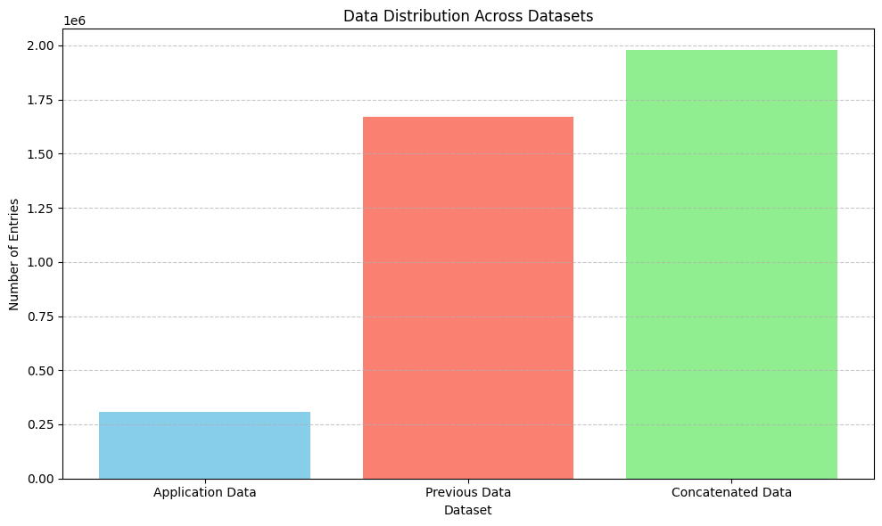

```python
import matplotlib.pyplot as plt

# Data for the plot
datasets = ['Application Data', 'Previous Data', 'Concatenated Data']
entries = [307511, 1670214, 307511 + 1670214]

# Create the bar plot
plt.figure(figsize=(10, 6))
plt.bar(datasets, entries, color=['skyblue', 'salmon', 'lightgreen'])
plt.xlabel('Dataset')
plt.ylabel('Number of Entries')
plt.title('Data Distribution Across Datasets')
plt.grid(axis='y', linestyle='--', alpha=0.7)

# Show plot
plt.tight_layout()
plt.show()
```

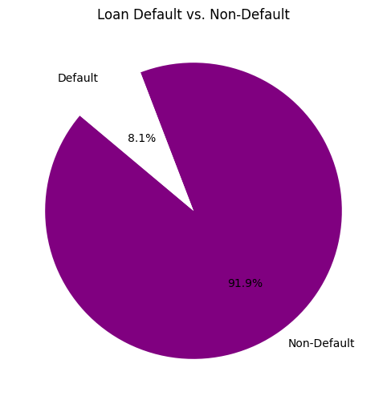

```python
import matplotlib.pyplot as plt

# Assuming 'TARGET' column in your 'app_data_x' DataFrame represents loan default
default_counts = app_data_x['TARGET'].value_counts()

# Labels and sizes
labels = ['Non-Default', 'Default']
sizes = default_counts.sort_index()  # Ensure the order is correct

# Plot
plt.figure(figsize=(8, 6))
plt.pie(sizes, labels=labels, autopct='%1.1f%%', startangle=140, colors=['purple', 'white'])
plt.title('Loan Default vs. Non-Default')
plt.show()
```

# Notes:

## Application Dataset (app_data):

1. Contains information about loan applications, such as the client's demographic data, loan details, and various flags that indicate different statuses or features of the loan or client.

## Previous Application Dataset (prev_app_data):

2. Includes details about previous loan applications made by the same clients, providing historical data that can be used to analyze patterns or behaviors over time.

## Columns Description Dataset (col_data):

3. Offers descriptions of the columns in the datasets, helping to understand what each field represents, which is crucial for proper data analysis and feature engineering.

# ------------------------------------------------------------------------------------------------------------

# Exploratory Data Analysis (EDA)

### Application_data:

Contains information about loan applications.

```python
app_data.head()
```

|  | SK_ID_CURR | TARGET | NAME_CONTRACT_TYPE | CODE_GENDER | FLAG_OWN_CAR | FLAG_OWN_REALTY | CNT_CHILDREN | AMT_INCOME_TOTAL | AMT_CREDIT | AMT_ANNUITY | ... | FLAG_DOCUMENT_18 | FLAG_DOCUMENT_19 | FLAG_DOCUMENT_20 | FLAG_DOCUMENT_21 | AMT_REQ_CREDIT_BUREAU_HOUR | AMT_REQ_CREDIT_BUREAU_DAY | AMT_REQ_CREDIT_BUREAU_WEEK | AMT_REQ_CREDIT_BUREAU_MON | AMT_REQ_CREDIT_BUREAU_QRT | AMT_REQ_CREDIT_BUREAU_YEAR |
| --- | --- | --- | --- | --- | --- | --- | --- | --- | --- | --- | --- | --- | --- | --- | --- | --- | --- | --- | --- | --- | --- |
| 0 | 100002 | 1 | Cash loans | M | N | Y | 0 | 202500.0 | 406597.5 | 24700.5 | ... | 0 | 0 | 0 | 0 | 0.0 | 0.0 | 0.0 | 0.0 | 0.0 | 1.0 |
| 1 | 100003 | 0 | Cash loans | F | N | N | 0 | 270000.0 | 1293502.5 | 35698.5 | ... | 0 | 0 | 0 | 0 | 0.0 | 0.0 | 0.0 | 0.0 | 0.0 | 0.0 |
| 2 | 100004 | 0 | Revolving loans | M | Y | Y | 0 | 67500.0 | 135000.0 | 6750.0 | ... | 0 | 0 | 0 | 0 | 0.0 | 0.0 | 0.0 | 0.0 | 0.0 | 0.0 |
| 3 | 100006 | 0 | Cash loans | F | N | Y | 0 | 135000.0 | 312682.5 | 29686.5 | ... | 0 | 0 | 0 | 0 | NaN | NaN | NaN | NaN | NaN | NaN |
| 4 | 100007 | 0 | Cash loans | M | N | Y | 0 | 121500.0 | 513000.0 | 21865.5 | ... | 0 | 0 | 0 | 0 | 0.0 | 0.0 | 0.0 | 0.0 | 0.0 | 0.0 |

5 rows × 122 columns

```python
app_data.tail()
```

|  | SK_ID_CURR | TARGET | NAME_CONTRACT_TYPE | CODE_GENDER | FLAG_OWN_CAR | FLAG_OWN_REALTY | CNT_CHILDREN | AMT_INCOME_TOTAL | AMT_CREDIT | AMT_ANNUITY | ... | FLAG_DOCUMENT_18 | FLAG_DOCUMENT_19 | FLAG_DOCUMENT_20 | FLAG_DOCUMENT_21 | AMT_REQ_CREDIT_BUREAU_HOUR | AMT_REQ_CREDIT_BUREAU_DAY | AMT_REQ_CREDIT_BUREAU_WEEK | AMT_REQ_CREDIT_BUREAU_MON | AMT_REQ_CREDIT_BUREAU_QRT | AMT_REQ_CREDIT_BUREAU_YEAR |
| --- | --- | --- | --- | --- | --- | --- | --- | --- | --- | --- | --- | --- | --- | --- | --- | --- | --- | --- | --- | --- | --- |
| 307506 | 456251 | 0 | Cash loans | M | N | N | 0 | 157500.0 | 254700.0 | 27558.0 | ... | 0 | 0 | 0 | 0 | NaN | NaN | NaN | NaN | NaN | NaN |
| 307507 | 456252 | 0 | Cash loans | F | N | Y | 0 | 72000.0 | 269550.0 | 12001.5 | ... | 0 | 0 | 0 | 0 | NaN | NaN | NaN | NaN | NaN | NaN |
| 307508 | 456253 | 0 | Cash loans | F | N | Y | 0 | 153000.0 | 677664.0 | 29979.0 | ... | 0 | 0 | 0 | 0 | 1.0 | 0.0 | 0.0 | 1.0 | 0.0 | 1.0 |
| 307509 | 456254 | 1 | Cash loans | F | N | Y | 0 | 171000.0 | 370107.0 | 20205.0 | ... | 0 | 0 | 0 | 0 | 0.0 | 0.0 | 0.0 | 0.0 | 0.0 | 0.0 |
| 307510 | 456255 | 0 | Cash loans | F | N | N | 0 | 157500.0 | 675000.0 | 49117.5 | ... | 0 | 0 | 0 | 0 | 0.0 | 0.0 | 0.0 | 2.0 | 0.0 | 1.0 |

5 rows × 122 columns

```python
print(app_data.dtypes.to_string())
```

```
SK_ID_CURR                        int64
TARGET                            int64
NAME_CONTRACT_TYPE               object
CODE_GENDER                      object
FLAG_OWN_CAR                     object
FLAG_OWN_REALTY                  object
CNT_CHILDREN                      int64
AMT_INCOME_TOTAL                float64
AMT_CREDIT                      float64
AMT_ANNUITY                     float64
AMT_GOODS_PRICE                 float64
NAME_TYPE_SUITE                  object
NAME_INCOME_TYPE                 object
NAME_EDUCATION_TYPE              object
NAME_FAMILY_STATUS               object
NAME_HOUSING_TYPE                object
REGION_POPULATION_RELATIVE      float64
DAYS_BIRTH                        int64
DAYS_EMPLOYED                     int64
DAYS_REGISTRATION               float64
DAYS_ID_PUBLISH                   int64
OWN_CAR_AGE                     float64
FLAG_MOBIL                        int64
FLAG_EMP_PHONE                    int64
FLAG_WORK_PHONE                   int64
FLAG_CONT_MOBILE                  int64
FLAG_PHONE                        int64
FLAG_EMAIL                        int64
OCCUPATION_TYPE                  object
CNT_FAM_MEMBERS                 float64
REGION_RATING_CLIENT              int64
REGION_RATING_CLIENT_W_CITY       int64
WEEKDAY_APPR_PROCESS_START       object
HOUR_APPR_PROCESS_START           int64
REG_REGION_NOT_LIVE_REGION        int64
REG_REGION_NOT_WORK_REGION        int64
LIVE_REGION_NOT_WORK_REGION       int64
REG_CITY_NOT_LIVE_CITY            int64
REG_CITY_NOT_WORK_CITY            int64
LIVE_CITY_NOT_WORK_CITY           int64
```

[output cut: 67 more lines]

```
FLAG_DOCUMENT_13                  int64
FLAG_DOCUMENT_14                  int64
FLAG_DOCUMENT_15                  int64
FLAG_DOCUMENT_16                  int64
FLAG_DOCUMENT_17                  int64
FLAG_DOCUMENT_18                  int64
FLAG_DOCUMENT_19                  int64
FLAG_DOCUMENT_20                  int64
FLAG_DOCUMENT_21                  int64
AMT_REQ_CREDIT_BUREAU_HOUR      float64
AMT_REQ_CREDIT_BUREAU_DAY       float64
AMT_REQ_CREDIT_BUREAU_WEEK      float64
AMT_REQ_CREDIT_BUREAU_MON       float64
AMT_REQ_CREDIT_BUREAU_QRT       float64
AMT_REQ_CREDIT_BUREAU_YEAR      float64
```

```python
app_data.info()
```

```
<class 'pandas.core.frame.DataFrame'>
RangeIndex: 307511 entries, 0 to 307510
Columns: 122 entries, SK_ID_CURR to AMT_REQ_CREDIT_BUREAU_YEAR
dtypes: float64(65), int64(41), object(16)
memory usage: 286.2+ MB
```

Contains 307,511 entries with 122 columns.</br> Columns include various types of data, such as identifiers, categorical variables, and the target variable.

```python
app_data.describe()
```

|  | SK_ID_CURR | TARGET | CNT_CHILDREN | AMT_INCOME_TOTAL | AMT_CREDIT | AMT_ANNUITY | AMT_GOODS_PRICE | REGION_POPULATION_RELATIVE | DAYS_BIRTH | DAYS_EMPLOYED | ... | FLAG_DOCUMENT_18 | FLAG_DOCUMENT_19 | FLAG_DOCUMENT_20 | FLAG_DOCUMENT_21 | AMT_REQ_CREDIT_BUREAU_HOUR | AMT_REQ_CREDIT_BUREAU_DAY | AMT_REQ_CREDIT_BUREAU_WEEK | AMT_REQ_CREDIT_BUREAU_MON | AMT_REQ_CREDIT_BUREAU_QRT | AMT_REQ_CREDIT_BUREAU_YEAR |
| --- | --- | --- | --- | --- | --- | --- | --- | --- | --- | --- | --- | --- | --- | --- | --- | --- | --- | --- | --- | --- | --- |
| count | 307511.000000 | 307511.000000 | 307511.000000 | 3.075110e+05 | 3.075110e+05 | 307499.000000 | 3.072330e+05 | 307511.000000 | 307511.000000 | 307511.000000 | ... | 307511.000000 | 307511.000000 | 307511.000000 | 307511.000000 | 265992.000000 | 265992.000000 | 265992.000000 | 265992.000000 | 265992.000000 | 265992.000000 |
| mean | 278180.518577 | 0.080729 | 0.417052 | 1.687979e+05 | 5.990260e+05 | 27108.573909 | 5.383962e+05 | 0.020868 | -16036.995067 | 63815.045904 | ... | 0.008130 | 0.000595 | 0.000507 | 0.000335 | 0.006402 | 0.007000 | 0.034362 | 0.267395 | 0.265474 | 1.899974 |
| std | 102790.175348 | 0.272419 | 0.722121 | 2.371231e+05 | 4.024908e+05 | 14493.737315 | 3.694465e+05 | 0.013831 | 4363.988632 | 141275.766519 | ... | 0.089798 | 0.024387 | 0.022518 | 0.018299 | 0.083849 | 0.110757 | 0.204685 | 0.916002 | 0.794056 | 1.869295 |
| min | 100002.000000 | 0.000000 | 0.000000 | 2.565000e+04 | 4.500000e+04 | 1615.500000 | 4.050000e+04 | 0.000290 | -25229.000000 | -17912.000000 | ... | 0.000000 | 0.000000 | 0.000000 | 0.000000 | 0.000000 | 0.000000 | 0.000000 | 0.000000 | 0.000000 | 0.000000 |
| 25% | 189145.500000 | 0.000000 | 0.000000 | 1.125000e+05 | 2.700000e+05 | 16524.000000 | 2.385000e+05 | 0.010006 | -19682.000000 | -2760.000000 | ... | 0.000000 | 0.000000 | 0.000000 | 0.000000 | 0.000000 | 0.000000 | 0.000000 | 0.000000 | 0.000000 | 0.000000 |
| 50% | 278202.000000 | 0.000000 | 0.000000 | 1.471500e+05 | 5.135310e+05 | 24903.000000 | 4.500000e+05 | 0.018850 | -15750.000000 | -1213.000000 | ... | 0.000000 | 0.000000 | 0.000000 | 0.000000 | 0.000000 | 0.000000 | 0.000000 | 0.000000 | 0.000000 | 1.000000 |
| 75% | 367142.500000 | 0.000000 | 1.000000 | 2.025000e+05 | 8.086500e+05 | 34596.000000 | 6.795000e+05 | 0.028663 | -12413.000000 | -289.000000 | ... | 0.000000 | 0.000000 | 0.000000 | 0.000000 | 0.000000 | 0.000000 | 0.000000 | 0.000000 | 0.000000 | 3.000000 |
| max | 456255.000000 | 1.000000 | 19.000000 | 1.170000e+08 | 4.050000e+06 | 258025.500000 | 4.050000e+06 | 0.072508 | -7489.000000 | 365243.000000 | ... | 1.000000 | 1.000000 | 1.000000 | 1.000000 | 4.000000 | 9.000000 | 8.000000 | 27.000000 | 261.000000 | 25.000000 |

8 rows × 106 columns

1. Count: Number of non-missing values per column.
2. Mean: Average value.
3. Std: Standard deviation, showing data spread.
4. Min/Max: Minimum and maximum values.
5. 25%/50%/75%: Quartiles, indicating data distribution.

```python
app_data.describe().T
```

|  | count | mean | std | min | 25% | 50% | 75% | max |
| --- | --- | --- | --- | --- | --- | --- | --- | --- |
| SK_ID_CURR | 307511.0 | 278180.518577 | 102790.175348 | 100002.0 | 189145.5 | 278202.0 | 367142.5 | 456255.0 |
| TARGET | 307511.0 | 0.080729 | 0.272419 | 0.0 | 0.0 | 0.0 | 0.0 | 1.0 |
| CNT_CHILDREN | 307511.0 | 0.417052 | 0.722121 | 0.0 | 0.0 | 0.0 | 1.0 | 19.0 |
| AMT_INCOME_TOTAL | 307511.0 | 168797.919297 | 237123.146279 | 25650.0 | 112500.0 | 147150.0 | 202500.0 | 117000000.0 |
| AMT_CREDIT | 307511.0 | 599025.999706 | 402490.776996 | 45000.0 | 270000.0 | 513531.0 | 808650.0 | 4050000.0 |
| ... | ... | ... | ... | ... | ... | ... | ... | ... |
| AMT_REQ_CREDIT_BUREAU_DAY | 265992.0 | 0.007000 | 0.110757 | 0.0 | 0.0 | 0.0 | 0.0 | 9.0 |
| AMT_REQ_CREDIT_BUREAU_WEEK | 265992.0 | 0.034362 | 0.204685 | 0.0 | 0.0 | 0.0 | 0.0 | 8.0 |
| AMT_REQ_CREDIT_BUREAU_MON | 265992.0 | 0.267395 | 0.916002 | 0.0 | 0.0 | 0.0 | 0.0 | 27.0 |
| AMT_REQ_CREDIT_BUREAU_QRT | 265992.0 | 0.265474 | 0.794056 | 0.0 | 0.0 | 0.0 | 0.0 | 261.0 |
| AMT_REQ_CREDIT_BUREAU_YEAR | 265992.0 | 1.899974 | 1.869295 | 0.0 | 0.0 | 1.0 | 3.0 | 25.0 |

106 rows × 8 columns

```python
print(app_data.columns)
```

```
Index(['SK_ID_CURR', 'TARGET', 'NAME_CONTRACT_TYPE', 'CODE_GENDER',
       'FLAG_OWN_CAR', 'FLAG_OWN_REALTY', 'CNT_CHILDREN', 'AMT_INCOME_TOTAL',
       'AMT_CREDIT', 'AMT_ANNUITY',
       ...
       'FLAG_DOCUMENT_18', 'FLAG_DOCUMENT_19', 'FLAG_DOCUMENT_20',
       'FLAG_DOCUMENT_21', 'AMT_REQ_CREDIT_BUREAU_HOUR',
       'AMT_REQ_CREDIT_BUREAU_DAY', 'AMT_REQ_CREDIT_BUREAU_WEEK',
       'AMT_REQ_CREDIT_BUREAU_MON', 'AMT_REQ_CREDIT_BUREAU_QRT',
       'AMT_REQ_CREDIT_BUREAU_YEAR'],
      dtype='object', length=122)
```

```python
app_data.shape
```

```
(307511, 122)
```

Target Variable Distribution:

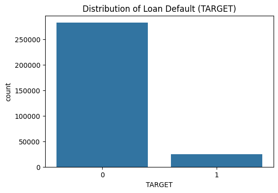

```python
# Plot distribution of the target variable
plt.figure(figsize=(6, 4))
sns.countplot(data=app_data, x='TARGET')
plt.title('Distribution of Loan Default (TARGET)')
plt.show()
```

Imbalanced data

```python
from collections import Counter

class_distribution = Counter(app_data['TARGET'])
print(class_distribution)
```

```
Counter({0: 282686, 1: 24825})
```

1. 0 (Non-default cases): 282,686 instances (about 92%).
2. 1 (Default cases): 24,825 instances (about 8%).

# SMOTE:

SMOTE is used to ensure that the model has a balanced dataset, which can lead to better performance and more reliable predictions.

other ways to reduce imbalance:

1. Undersampling
   1. Risk of losing important information by removing majority class samples, which can lead to underfitting.
2. Oversampling
   1. Can lead to overfitting as the same instances are repeated multiple times.

SMOTE:Reduces overfitting compared to simple oversampling and provides a more robust solution by creating new data points.

```python
# Prepare data for SMOTE
# Extract features and target variable
X = app_data.drop(columns=['TARGET'])
y = app_data['TARGET']
```

PURPOSE:

1. Preprocessing ensures that your features are in the right format and scaled appropriately.
2. SMOTE helps to address class imbalance by generating synthetic examples for the minority class, which can improve model performance.

```python
# SMOTE (Synthetic Minority Over-sampling Technique)

# Identify categorical and numerical columns
categorical_cols = X.select_dtypes(include=['object']).columns
numerical_cols = X.select_dtypes(include=['int64', 'float64']).columns

# Preprocessing for numerical data: Scaling and imputation
numerical_transformer = Pipeline(steps=[
    ('imputer', SimpleImputer(strategy='median')),
    ('scaler', StandardScaler())
])
# median :As it provides a central value without being skewed by extreme values.

# Preprocessing for categorical data: Imputation and encoding
categorical_transformer = Pipeline(steps=[
    ('imputer', SimpleImputer(strategy='most_frequent')),
    ('onehot', OneHotEncoder(handle_unknown='ignore'))
])
# Mode :It ensures that the most common category is used to fill missing values, which often reflects the typical data pattern.
# one-hot encoding is used to transform categorical data into a numerical format suitable for machine learning


# Bundle preprocessing for numerical and categorical data
preprocessor = ColumnTransformer(
    transformers=[
        ('num', numerical_transformer, numerical_cols),
        ('cat', categorical_transformer, categorical_cols)
    ])

# helps you manage and apply different preprocessing techniques to different types of data efficiently and consistently.

# Preprocess the features
X_preprocessed = preprocessor.fit_transform(X)

# TO apply the transformations (scaling, encoding) in a single call.


# Apply SMOTE
smote = SMOTE(random_state=42)
X_resampled, y_resampled = smote.fit_resample(X_preprocessed, y)

# Checking the new class distribution
print("Original class distribution:", Counter(y))
print("Resampled class distribution:", Counter(y_resampled))
```

```
Original class distribution: Counter({0: 282686, 1: 24825})
Resampled class distribution: Counter({1: 282686, 0: 282686})
```

```
Original class distribution: Counter({0: 282686, 1: 24825})
Resampled class distribution: Counter({1: 282686, 0: 282686})
```

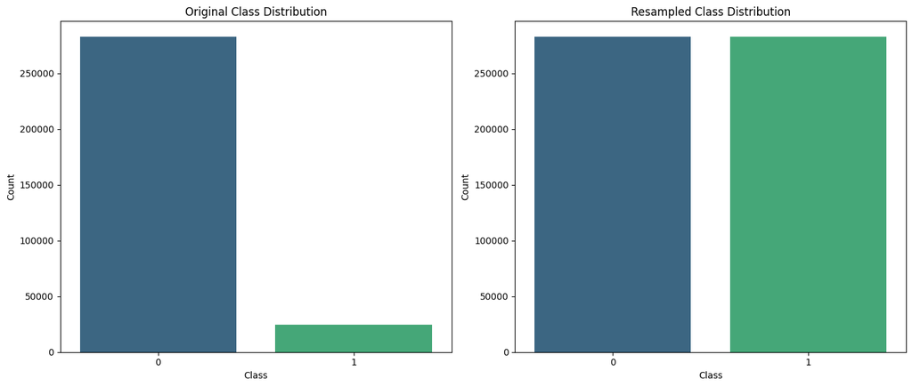

```python
# Original class distribution
original_class_distribution = Counter(y)
print("Original class distribution:", original_class_distribution)

# Resampled class distribution
resampled_class_distribution = Counter(y_resampled)
print("Resampled class distribution:", resampled_class_distribution)

# Plotting class distribution before and after SMOTE
fig, ax = plt.subplots(1, 2, figsize=(14, 6))

# Original class distribution plot
sns.barplot(x=list(original_class_distribution.keys()), y=list(original_class_distribution.values()), ax=ax[0], palette='viridis')
ax[0].set_title('Original Class Distribution')
ax[0].set_xlabel('Class')
ax[0].set_ylabel('Count')

# Resampled class distribution plot
sns.barplot(x=list(resampled_class_distribution.keys()), y=list(resampled_class_distribution.values()), ax=ax[1], palette='viridis')
ax[1].set_title('Resampled Class Distribution')
ax[1].set_xlabel('Class')
ax[1].set_ylabel('Count')

plt.tight_layout()
plt.show()
```

1. **Size:** 307,511 rows, 122 columns
2. **Key Columns:** SK_ID_CURR (unique identifier), TARGET (target variable), NAME_CONTRACT_TYPE, CODE_GENDER, AMT_INCOME_TOTAL, AMT_CREDIT, AMT_ANNUITY, etc.
3. **Data Types:** Mostly numeric (floats and integers), some categorical (objects).
4. **Summary:** Includes various financial details and demographic information about applicants.

### Previous_application_df:

Contains historical data on previous loan applications.

```python
prev_app_data.head()
```

|  | SK_ID_PREV | SK_ID_CURR | NAME_CONTRACT_TYPE | AMT_ANNUITY | AMT_APPLICATION | AMT_CREDIT | AMT_DOWN_PAYMENT | AMT_GOODS_PRICE | WEEKDAY_APPR_PROCESS_START | HOUR_APPR_PROCESS_START | ... | NAME_SELLER_INDUSTRY | CNT_PAYMENT | NAME_YIELD_GROUP | PRODUCT_COMBINATION | DAYS_FIRST_DRAWING | DAYS_FIRST_DUE | DAYS_LAST_DUE_1ST_VERSION | DAYS_LAST_DUE | DAYS_TERMINATION | NFLAG_INSURED_ON_APPROVAL |
| --- | --- | --- | --- | --- | --- | --- | --- | --- | --- | --- | --- | --- | --- | --- | --- | --- | --- | --- | --- | --- | --- |
| 0 | 2030495 | 271877 | Consumer loans | 1730.430 | 17145.0 | 17145.0 | 0.0 | 17145.0 | SATURDAY | 15 | ... | Connectivity | 12.0 | middle | POS mobile with interest | 365243.0 | -42.0 | 300.0 | -42.0 | -37.0 | 0.0 |
| 1 | 2802425 | 108129 | Cash loans | 25188.615 | 607500.0 | 679671.0 | NaN | 607500.0 | THURSDAY | 11 | ... | XNA | 36.0 | low_action | Cash X-Sell: low | 365243.0 | -134.0 | 916.0 | 365243.0 | 365243.0 | 1.0 |
| 2 | 2523466 | 122040 | Cash loans | 15060.735 | 112500.0 | 136444.5 | NaN | 112500.0 | TUESDAY | 11 | ... | XNA | 12.0 | high | Cash X-Sell: high | 365243.0 | -271.0 | 59.0 | 365243.0 | 365243.0 | 1.0 |
| 3 | 2819243 | 176158 | Cash loans | 47041.335 | 450000.0 | 470790.0 | NaN | 450000.0 | MONDAY | 7 | ... | XNA | 12.0 | middle | Cash X-Sell: middle | 365243.0 | -482.0 | -152.0 | -182.0 | -177.0 | 1.0 |
| 4 | 1784265 | 202054 | Cash loans | 31924.395 | 337500.0 | 404055.0 | NaN | 337500.0 | THURSDAY | 9 | ... | XNA | 24.0 | high | Cash Street: high | NaN | NaN | NaN | NaN | NaN | NaN |

5 rows × 37 columns

```python
prev_app_data.tail()
```

|  | SK_ID_PREV | SK_ID_CURR | NAME_CONTRACT_TYPE | AMT_ANNUITY | AMT_APPLICATION | AMT_CREDIT | AMT_DOWN_PAYMENT | AMT_GOODS_PRICE | WEEKDAY_APPR_PROCESS_START | HOUR_APPR_PROCESS_START | ... | NAME_SELLER_INDUSTRY | CNT_PAYMENT | NAME_YIELD_GROUP | PRODUCT_COMBINATION | DAYS_FIRST_DRAWING | DAYS_FIRST_DUE | DAYS_LAST_DUE_1ST_VERSION | DAYS_LAST_DUE | DAYS_TERMINATION | NFLAG_INSURED_ON_APPROVAL |
| --- | --- | --- | --- | --- | --- | --- | --- | --- | --- | --- | --- | --- | --- | --- | --- | --- | --- | --- | --- | --- | --- |
| 1670209 | 2300464 | 352015 | Consumer loans | 14704.290 | 267295.5 | 311400.0 | 0.0 | 267295.5 | WEDNESDAY | 12 | ... | Furniture | 30.0 | low_normal | POS industry with interest | 365243.0 | -508.0 | 362.0 | -358.0 | -351.0 | 0.0 |
| 1670210 | 2357031 | 334635 | Consumer loans | 6622.020 | 87750.0 | 64291.5 | 29250.0 | 87750.0 | TUESDAY | 15 | ... | Furniture | 12.0 | middle | POS industry with interest | 365243.0 | -1604.0 | -1274.0 | -1304.0 | -1297.0 | 0.0 |
| 1670211 | 2659632 | 249544 | Consumer loans | 11520.855 | 105237.0 | 102523.5 | 10525.5 | 105237.0 | MONDAY | 12 | ... | Consumer electronics | 10.0 | low_normal | POS household with interest | 365243.0 | -1457.0 | -1187.0 | -1187.0 | -1181.0 | 0.0 |
| 1670212 | 2785582 | 400317 | Cash loans | 18821.520 | 180000.0 | 191880.0 | NaN | 180000.0 | WEDNESDAY | 9 | ... | XNA | 12.0 | low_normal | Cash X-Sell: low | 365243.0 | -1155.0 | -825.0 | -825.0 | -817.0 | 1.0 |
| 1670213 | 2418762 | 261212 | Cash loans | 16431.300 | 360000.0 | 360000.0 | NaN | 360000.0 | SUNDAY | 10 | ... | XNA | 48.0 | middle | Cash X-Sell: middle | 365243.0 | -1163.0 | 247.0 | -443.0 | -423.0 | 0.0 |

5 rows × 37 columns

```python
prev_app_data.dtypes
```

|  | 0 |
| --- | --- |
| SK_ID_PREV | int64 |
| SK_ID_CURR | int64 |
| NAME_CONTRACT_TYPE | object |
| AMT_ANNUITY | float64 |
| AMT_APPLICATION | float64 |
| AMT_CREDIT | float64 |
| AMT_DOWN_PAYMENT | float64 |
| AMT_GOODS_PRICE | float64 |
| WEEKDAY_APPR_PROCESS_START | object |
| HOUR_APPR_PROCESS_START | int64 |
| FLAG_LAST_APPL_PER_CONTRACT | object |
| NFLAG_LAST_APPL_IN_DAY | int64 |
| RATE_DOWN_PAYMENT | float64 |
| RATE_INTEREST_PRIMARY | float64 |
| RATE_INTEREST_PRIVILEGED | float64 |
| NAME_CASH_LOAN_PURPOSE | object |
| NAME_CONTRACT_STATUS | object |
| DAYS_DECISION | int64 |
| NAME_PAYMENT_TYPE | object |
| CODE_REJECT_REASON | object |
| NAME_TYPE_SUITE | object |
| NAME_CLIENT_TYPE | object |
| NAME_GOODS_CATEGORY | object |
| NAME_PORTFOLIO | object |
| NAME_PRODUCT_TYPE | object |
| CHANNEL_TYPE | object |
| SELLERPLACE_AREA | int64 |
| NAME_SELLER_INDUSTRY | object |
| CNT_PAYMENT | float64 |
| NAME_YIELD_GROUP | object |
| PRODUCT_COMBINATION | object |
| DAYS_FIRST_DRAWING | float64 |
| DAYS_FIRST_DUE | float64 |
| DAYS_LAST_DUE_1ST_VERSION | float64 |
| DAYS_LAST_DUE | float64 |
| DAYS_TERMINATION | float64 |
| NFLAG_INSURED_ON_APPROVAL | float64 |

**dtype:** object

```python
prev_app_data.info()
```

```
<class 'pandas.core.frame.DataFrame'>
RangeIndex: 1670214 entries, 0 to 1670213
Data columns (total 37 columns):
 #   Column                       Non-Null Count    Dtype
---  ------                       --------------    -----
 0   SK_ID_PREV                   1670214 non-null  int64
 1   SK_ID_CURR                   1670214 non-null  int64
 2   NAME_CONTRACT_TYPE           1670214 non-null  object
 3   AMT_ANNUITY                  1297979 non-null  float64
 4   AMT_APPLICATION              1670214 non-null  float64
 5   AMT_CREDIT                   1670213 non-null  float64
 6   AMT_DOWN_PAYMENT             774370 non-null   float64
 7   AMT_GOODS_PRICE              1284699 non-null  float64
 8   WEEKDAY_APPR_PROCESS_START   1670214 non-null  object
 9   HOUR_APPR_PROCESS_START      1670214 non-null  int64
```

[output cut: 29 more lines]

Contains 1,670,214 entries with 37 columns.</br> Data is linked to the application_data.csv through SK_ID_CURR.

```python
prev_app_data.columns
```

```
Index(['SK_ID_PREV', 'SK_ID_CURR', 'NAME_CONTRACT_TYPE', 'AMT_ANNUITY',
       'AMT_APPLICATION', 'AMT_CREDIT', 'AMT_DOWN_PAYMENT', 'AMT_GOODS_PRICE',
       'WEEKDAY_APPR_PROCESS_START', 'HOUR_APPR_PROCESS_START',
       'FLAG_LAST_APPL_PER_CONTRACT', 'NFLAG_LAST_APPL_IN_DAY',
       'RATE_DOWN_PAYMENT', 'RATE_INTEREST_PRIMARY',
       'RATE_INTEREST_PRIVILEGED', 'NAME_CASH_LOAN_PURPOSE',
       'NAME_CONTRACT_STATUS', 'DAYS_DECISION', 'NAME_PAYMENT_TYPE',
       'CODE_REJECT_REASON', 'NAME_TYPE_SUITE', 'NAME_CLIENT_TYPE',
       'NAME_GOODS_CATEGORY', 'NAME_PORTFOLIO', 'NAME_PRODUCT_TYPE',
       'CHANNEL_TYPE', 'SELLERPLACE_AREA', 'NAME_SELLER_INDUSTRY',
       'CNT_PAYMENT', 'NAME_YIELD_GROUP', 'PRODUCT_COMBINATION',
       'DAYS_FIRST_DRAWING', 'DAYS_FIRST_DUE', 'DAYS_LAST_DUE_1ST_VERSION',
       'DAYS_LAST_DUE', 'DAYS_TERMINATION', 'NFLAG_INSURED_ON_APPROVAL'],
      dtype='object')
```

```python
prev_app_data.describe()
```

|  | SK_ID_PREV | SK_ID_CURR | AMT_ANNUITY | AMT_APPLICATION | AMT_CREDIT | AMT_DOWN_PAYMENT | AMT_GOODS_PRICE | HOUR_APPR_PROCESS_START | NFLAG_LAST_APPL_IN_DAY | RATE_DOWN_PAYMENT | ... | RATE_INTEREST_PRIVILEGED | DAYS_DECISION | SELLERPLACE_AREA | CNT_PAYMENT | DAYS_FIRST_DRAWING | DAYS_FIRST_DUE | DAYS_LAST_DUE_1ST_VERSION | DAYS_LAST_DUE | DAYS_TERMINATION | NFLAG_INSURED_ON_APPROVAL |
| --- | --- | --- | --- | --- | --- | --- | --- | --- | --- | --- | --- | --- | --- | --- | --- | --- | --- | --- | --- | --- | --- |
| count | 1.670214e+06 | 1.670214e+06 | 1.297979e+06 | 1.670214e+06 | 1.670213e+06 | 7.743700e+05 | 1.284699e+06 | 1.670214e+06 | 1.670214e+06 | 774370.000000 | ... | 5951.000000 | 1.670214e+06 | 1.670214e+06 | 1.297984e+06 | 997149.000000 | 997149.000000 | 997149.000000 | 997149.000000 | 997149.000000 | 997149.000000 |
| mean | 1.923089e+06 | 2.783572e+05 | 1.595512e+04 | 1.752339e+05 | 1.961140e+05 | 6.697402e+03 | 2.278473e+05 | 1.248418e+01 | 9.964675e-01 | 0.079637 | ... | 0.773503 | -8.806797e+02 | 3.139511e+02 | 1.605408e+01 | 342209.855039 | 13826.269337 | 33767.774054 | 76582.403064 | 81992.343838 | 0.332570 |
| std | 5.325980e+05 | 1.028148e+05 | 1.478214e+04 | 2.927798e+05 | 3.185746e+05 | 2.092150e+04 | 3.153966e+05 | 3.334028e+00 | 5.932963e-02 | 0.107823 | ... | 0.100879 | 7.790997e+02 | 7.127443e+03 | 1.456729e+01 | 88916.115833 | 72444.869708 | 106857.034789 | 149647.415123 | 153303.516729 | 0.471134 |
| min | 1.000001e+06 | 1.000010e+05 | 0.000000e+00 | 0.000000e+00 | 0.000000e+00 | -9.000000e-01 | 0.000000e+00 | 0.000000e+00 | 0.000000e+00 | -0.000015 | ... | 0.373150 | -2.922000e+03 | -1.000000e+00 | 0.000000e+00 | -2922.000000 | -2892.000000 | -2801.000000 | -2889.000000 | -2874.000000 | 0.000000 |
| 25% | 1.461857e+06 | 1.893290e+05 | 6.321780e+03 | 1.872000e+04 | 2.416050e+04 | 0.000000e+00 | 5.084100e+04 | 1.000000e+01 | 1.000000e+00 | 0.000000 | ... | 0.715645 | -1.300000e+03 | -1.000000e+00 | 6.000000e+00 | 365243.000000 | -1628.000000 | -1242.000000 | -1314.000000 | -1270.000000 | 0.000000 |
| 50% | 1.923110e+06 | 2.787145e+05 | 1.125000e+04 | 7.104600e+04 | 8.054100e+04 | 1.638000e+03 | 1.123200e+05 | 1.200000e+01 | 1.000000e+00 | 0.051605 | ... | 0.835095 | -5.810000e+02 | 3.000000e+00 | 1.200000e+01 | 365243.000000 | -831.000000 | -361.000000 | -537.000000 | -499.000000 | 0.000000 |
| 75% | 2.384280e+06 | 3.675140e+05 | 2.065842e+04 | 1.803600e+05 | 2.164185e+05 | 7.740000e+03 | 2.340000e+05 | 1.500000e+01 | 1.000000e+00 | 0.108909 | ... | 0.852537 | -2.800000e+02 | 8.200000e+01 | 2.400000e+01 | 365243.000000 | -411.000000 | 129.000000 | -74.000000 | -44.000000 | 1.000000 |
| max | 2.845382e+06 | 4.562550e+05 | 4.180581e+05 | 6.905160e+06 | 6.905160e+06 | 3.060045e+06 | 6.905160e+06 | 2.300000e+01 | 1.000000e+00 | 1.000000 | ... | 1.000000 | -1.000000e+00 | 4.000000e+06 | 8.400000e+01 | 365243.000000 | 365243.000000 | 365243.000000 | 365243.000000 | 365243.000000 | 1.000000 |

8 rows × 21 columns

```python
prev_app_data.describe().T
```

|  | count | mean | std | min | 25% | 50% | 75% | max |
| --- | --- | --- | --- | --- | --- | --- | --- | --- |
| SK_ID_PREV | 1670214.0 | 1.923089e+06 | 532597.958696 | 1.000001e+06 | 1.461857e+06 | 1.923110e+06 | 2.384280e+06 | 2845382.000 |
| SK_ID_CURR | 1670214.0 | 2.783572e+05 | 102814.823849 | 1.000010e+05 | 1.893290e+05 | 2.787145e+05 | 3.675140e+05 | 456255.000 |
| AMT_ANNUITY | 1297979.0 | 1.595512e+04 | 14782.137335 | 0.000000e+00 | 6.321780e+03 | 1.125000e+04 | 2.065842e+04 | 418058.145 |
| AMT_APPLICATION | 1670214.0 | 1.752339e+05 | 292779.762386 | 0.000000e+00 | 1.872000e+04 | 7.104600e+04 | 1.803600e+05 | 6905160.000 |
| AMT_CREDIT | 1670213.0 | 1.961140e+05 | 318574.616547 | 0.000000e+00 | 2.416050e+04 | 8.054100e+04 | 2.164185e+05 | 6905160.000 |
| AMT_DOWN_PAYMENT | 774370.0 | 6.697402e+03 | 20921.495410 | -9.000000e-01 | 0.000000e+00 | 1.638000e+03 | 7.740000e+03 | 3060045.000 |
| AMT_GOODS_PRICE | 1284699.0 | 2.278473e+05 | 315396.557937 | 0.000000e+00 | 5.084100e+04 | 1.123200e+05 | 2.340000e+05 | 6905160.000 |
| HOUR_APPR_PROCESS_START | 1670214.0 | 1.248418e+01 | 3.334028 | 0.000000e+00 | 1.000000e+01 | 1.200000e+01 | 1.500000e+01 | 23.000 |
| NFLAG_LAST_APPL_IN_DAY | 1670214.0 | 9.964675e-01 | 0.059330 | 0.000000e+00 | 1.000000e+00 | 1.000000e+00 | 1.000000e+00 | 1.000 |
| RATE_DOWN_PAYMENT | 774370.0 | 7.963682e-02 | 0.107823 | -1.497876e-05 | 0.000000e+00 | 5.160508e-02 | 1.089091e-01 | 1.000 |
| RATE_INTEREST_PRIMARY | 5951.0 | 1.883569e-01 | 0.087671 | 3.478125e-02 | 1.607163e-01 | 1.891222e-01 | 1.933299e-01 | 1.000 |
| RATE_INTEREST_PRIVILEGED | 5951.0 | 7.735025e-01 | 0.100879 | 3.731501e-01 | 7.156448e-01 | 8.350951e-01 | 8.525370e-01 | 1.000 |
| DAYS_DECISION | 1670214.0 | -8.806797e+02 | 779.099667 | -2.922000e+03 | -1.300000e+03 | -5.810000e+02 | -2.800000e+02 | -1.000 |
| SELLERPLACE_AREA | 1670214.0 | 3.139511e+02 | 7127.443459 | -1.000000e+00 | -1.000000e+00 | 3.000000e+00 | 8.200000e+01 | 4000000.000 |
| CNT_PAYMENT | 1297984.0 | 1.605408e+01 | 14.567288 | 0.000000e+00 | 6.000000e+00 | 1.200000e+01 | 2.400000e+01 | 84.000 |
| DAYS_FIRST_DRAWING | 997149.0 | 3.422099e+05 | 88916.115833 | -2.922000e+03 | 3.652430e+05 | 3.652430e+05 | 3.652430e+05 | 365243.000 |
| DAYS_FIRST_DUE | 997149.0 | 1.382627e+04 | 72444.869708 | -2.892000e+03 | -1.628000e+03 | -8.310000e+02 | -4.110000e+02 | 365243.000 |
| DAYS_LAST_DUE_1ST_VERSION | 997149.0 | 3.376777e+04 | 106857.034789 | -2.801000e+03 | -1.242000e+03 | -3.610000e+02 | 1.290000e+02 | 365243.000 |
| DAYS_LAST_DUE | 997149.0 | 7.658240e+04 | 149647.415123 | -2.889000e+03 | -1.314000e+03 | -5.370000e+02 | -7.400000e+01 | 365243.000 |
| DAYS_TERMINATION | 997149.0 | 8.199234e+04 | 153303.516729 | -2.874000e+03 | -1.270000e+03 | -4.990000e+02 | -4.400000e+01 | 365243.000 |
| NFLAG_INSURED_ON_APPROVAL | 997149.0 | 3.325702e-01 | 0.471134 | 0.000000e+00 | 0.000000e+00 | 0.000000e+00 | 1.000000e+00 | 1.000 |

```python
prev_app_data.shape
```

```
(1670214, 37)
```

1. **Size:** 1,670,214 rows, 37 columns
2. **Key Columns:** SK_ID_PREV (unique identifier for previous applications), SK_ID_CURR (link to current application), AMT_ANNUITY, AMT_APPLICATION, AMT_CREDIT, WEEKDAY_APPR_PROCESS_START, etc.
3. **Data Types:** Mostly numeric and categorical.
4. **Summary:** Contains historical application details for each current application.

### Columns_description_df:

```python
col_data.head()
```

|  | Unnamed: 0 | Table | Row | Description | Special |
| --- | --- | --- | --- | --- | --- |
| 0 | 1 | application_data | SK_ID_CURR | ID of loan in our sample | NaN |
| 1 | 2 | application_data | TARGET | Target variable (1 - client with payment diffi... | NaN |
| 2 | 5 | application_data | NAME_CONTRACT_TYPE | Identification if loan is cash or revolving | NaN |
| 3 | 6 | application_data | CODE_GENDER | Gender of the client | NaN |
| 4 | 7 | application_data | FLAG_OWN_CAR | Flag if the client owns a car | NaN |

```python
col_data.tail()
```

|  | Unnamed: 0 | Table | Row | Description | Special |
| --- | --- | --- | --- | --- | --- |
| 155 | 209 | previous_application.csv | DAYS_FIRST_DUE | Relative to application date of current applic... | time only relative to the application |
| 156 | 210 | previous_application.csv | DAYS_LAST_DUE_1ST_VERSION | Relative to application date of current applic... | time only relative to the application |
| 157 | 211 | previous_application.csv | DAYS_LAST_DUE | Relative to application date of current applic... | time only relative to the application |
| 158 | 212 | previous_application.csv | DAYS_TERMINATION | Relative to application date of current applic... | time only relative to the application |
| 159 | 213 | previous_application.csv | NFLAG_INSURED_ON_APPROVAL | Did the client requested insurance during the ... | NaN |

```python
col_data.dtypes
```

|  | 0 |
| --- | --- |
| Unnamed: 0 | int64 |
| Table | object |
| Row | object |
| Description | object |
| Special | object |

**dtype:** object

```python
col_data.info()
```

```
<class 'pandas.core.frame.DataFrame'>
RangeIndex: 160 entries, 0 to 159
Data columns (total 5 columns):
 #   Column       Non-Null Count  Dtype
---  ------       --------------  -----
 0   Unnamed: 0   160 non-null    int64
 1   Table        160 non-null    object
 2   Row          160 non-null    object
 3   Description  160 non-null    object
 4   Special      69 non-null     object
dtypes: int64(1), object(4)
memory usage: 6.4+ KB
```

```python
col_data.columns
```

```
Index(['Unnamed: 0', 'Table', 'Row', 'Description', 'Special'], dtype='object')
```

```python
col_data.describe()
```

|  | Unnamed: 0 |
| --- | --- |
| count | 160.00000 |
| mean | 94.58750 |
| std | 64.12727 |
| min | 1.00000 |
| 25% | 42.75000 |
| 50% | 82.50000 |
| 75% | 122.25000 |
| max | 213.00000 |

```python
col_data.shape
```

```
(160, 5)
```

1. **Columns:** Includes the table name, row (column name), description, and any special notes.
2. **Purpose:** Provides descriptions for columns in both datasets, which will be useful later on.

#### Summary:

1. application_data.csv: Provides information on loan applications, including identifiers, loan types, applicant gender, and default status. The data structure and types suggest a need for handling categorical features and potential missing values.
2. previous_application.csv: Contains detailed records of previous applications, linked to the main application dataset, with columns detailing credit and application amounts. The large number of entries indicates a significant amount of historical data.
3. columns_description.csv: Serves as a reference for understanding the columns in the other datasets, helping to make sense of the data attributes and their implications.

# App_data

### Percentage of missing values

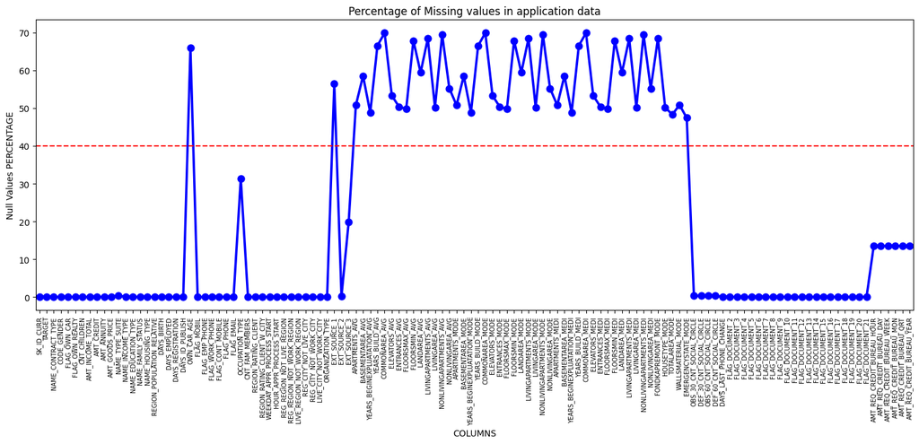

```python
null_application = pd.DataFrame((app_data.isnull().sum())*100/app_data.shape[0]).reset_index()
null_application.columns = ['column_name' , 'null_value_percentage']

fig = plt.figure(figsize=(18,6))
ax = sns.pointplot(x="column_name" , y="null_value_percentage" , data = null_application , color='blue')
plt.xticks(rotation=90,fontsize=7)
ax.axhline(40, ls='--',color='red')
plt.title("Percentage of Missing values in application data")
plt.ylabel("Null Values PERCENTAGE")
plt.xlabel("COLUMNS")
plt.show()
```

From the above plot , we can see the column having more than 40% null values are marked above the red line

```python
null_application_40 = null_application[null_application['null_value_percentage'] > 40]
null_application_40
```

|  | column_name | null_value_percentage |
| --- | --- | --- |
| 21 | OWN_CAR_AGE | 65.990810 |
| 41 | EXT_SOURCE_1 | 56.381073 |
| 44 | APARTMENTS_AVG | 50.749729 |
| 45 | BASEMENTAREA_AVG | 58.515956 |
| 46 | YEARS_BEGINEXPLUATATION_AVG | 48.781019 |
| 47 | YEARS_BUILD_AVG | 66.497784 |
| 48 | COMMONAREA_AVG | 69.872297 |
| 49 | ELEVATORS_AVG | 53.295980 |
| 50 | ENTRANCES_AVG | 50.348768 |
| 51 | FLOORSMAX_AVG | 49.760822 |
| 52 | FLOORSMIN_AVG | 67.848630 |
| 53 | LANDAREA_AVG | 59.376738 |
| 54 | LIVINGAPARTMENTS_AVG | 68.354953 |
| 55 | LIVINGAREA_AVG | 50.193326 |
| 56 | NONLIVINGAPARTMENTS_AVG | 69.432963 |
| 57 | NONLIVINGAREA_AVG | 55.179164 |
| 58 | APARTMENTS_MODE | 50.749729 |
| 59 | BASEMENTAREA_MODE | 58.515956 |
| 60 | YEARS_BEGINEXPLUATATION_MODE | 48.781019 |
| 61 | YEARS_BUILD_MODE | 66.497784 |
| 62 | COMMONAREA_MODE | 69.872297 |
| 63 | ELEVATORS_MODE | 53.295980 |
| 64 | ENTRANCES_MODE | 50.348768 |
| 65 | FLOORSMAX_MODE | 49.760822 |
| 66 | FLOORSMIN_MODE | 67.848630 |
| 67 | LANDAREA_MODE | 59.376738 |
| 68 | LIVINGAPARTMENTS_MODE | 68.354953 |
| 69 | LIVINGAREA_MODE | 50.193326 |
| 70 | NONLIVINGAPARTMENTS_MODE | 69.432963 |
| 71 | NONLIVINGAREA_MODE | 55.179164 |
| 72 | APARTMENTS_MEDI | 50.749729 |
| 73 | BASEMENTAREA_MEDI | 58.515956 |
| 74 | YEARS_BEGINEXPLUATATION_MEDI | 48.781019 |
| 75 | YEARS_BUILD_MEDI | 66.497784 |
| 76 | COMMONAREA_MEDI | 69.872297 |
| 77 | ELEVATORS_MEDI | 53.295980 |
| 78 | ENTRANCES_MEDI | 50.348768 |
| 79 | FLOORSMAX_MEDI | 49.760822 |
| 80 | FLOORSMIN_MEDI | 67.848630 |
| 81 | LANDAREA_MEDI | 59.376738 |
| 82 | LIVINGAPARTMENTS_MEDI | 68.354953 |
| 83 | LIVINGAREA_MEDI | 50.193326 |
| 84 | NONLIVINGAPARTMENTS_MEDI | 69.432963 |
| 85 | NONLIVINGAREA_MEDI | 55.179164 |
| 86 | FONDKAPREMONT_MODE | 68.386172 |
| 87 | HOUSETYPE_MODE | 50.176091 |
| 88 | TOTALAREA_MODE | 48.268517 |
| 89 | WALLSMATERIAL_MODE | 50.840783 |
| 90 | EMERGENCYSTATE_MODE | 47.398304 |

### Outliers in data

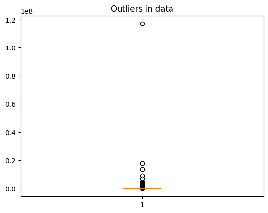

```python
plt.boxplot(app_data['AMT_INCOME_TOTAL']);
plt.title('Outliers in data');
```

Remove Outliers

```python
q3  = np.percentile(app_data['AMT_INCOME_TOTAL'],75)
q2 = np.percentile(app_data['AMT_INCOME_TOTAL'],25)
iqr = q3 -q2
ub = q3 +(1.5 * iqr)
lb = q2-(1.5 * iqr)

app_data  = app_data[(app_data['AMT_INCOME_TOTAL'] <= ub) & (app_data['AMT_INCOME_TOTAL'] >=lb)]
```

1. Percentiles (Q3 and Q2):

Imagine we have a sorted list of incomes. The 25th percentile (Q2) is the value that 25% of the people earn less than, and the 75th percentile (Q3) is the value that 75% of the people earn less than.

1. Q3 (75th percentile): Most people have incomes lower than this value.
2. Q2 (25th percentile): A smaller portion of people have incomes lower than this value.
1. Interquartile Range (IQR):
   1. The IQR is the difference between Q3 and Q2. It tells us how spread out the middle 50% of incomes are.
   2. Why it matters: We use this spread to identify what counts as a "normal" range for income.
2. Upper and Lower Bounds:
   1. We then define an upper bound (UB) and a lower bound (LB) for what we consider "normal" incomes.
   2. Upper Bound (UB): This is a bit higher than Q3.
   3. Lower Bound (LB): This is a bit lower than Q2.
   4. We extend the normal range by 1.5 times the IQR. This helps us decide what counts as an extreme income (an outlier).
3. Filtering the Data:
   1. We keep only those incomes that are within our "normal" range (between LB and UB).
   2. Result: This removes the very high and very low incomes that are considered outliers.

Plot after removing ouliers

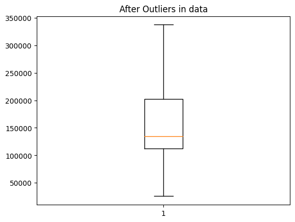

```python
plt.boxplot(app_data['AMT_INCOME_TOTAL']);
plt.title('After Outliers in data');
```

the box plot shows that the removal of outliers has improved the distribution of the AMT_INCOME_TOTAL column, making it more representative of the majority of the data.

```python
app_data['AMT_INCOME_TOTAL'].describe()
```

|  | AMT_INCOME_TOTAL |
| --- | --- |
| count | 293476.000000 |
| mean | 154263.935956 |
| std | 64014.949755 |
| min | 25650.000000 |
| 25% | 112500.000000 |
| 50% | 135000.000000 |
| 75% | 202500.000000 |
| max | 337500.000000 |

**dtype:** float64

### Distribution of the AMT_INCOME_TOTAL column in the app_data dataset.

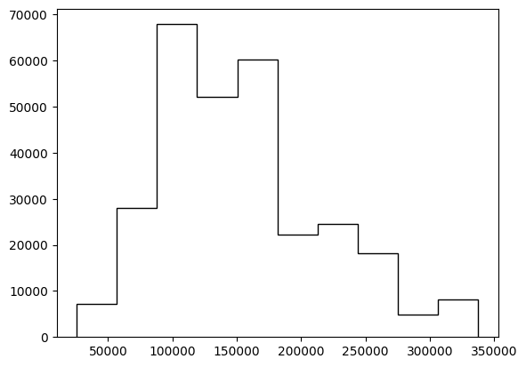

```python
plt.hist(app_data['AMT_INCOME_TOTAL'],histtype='step',color = 'black');
```

the graph shows that most individuals in the dataset have relatively low incomes, with a smaller number of individuals reporting higher incomes.

Checking the imbalance data

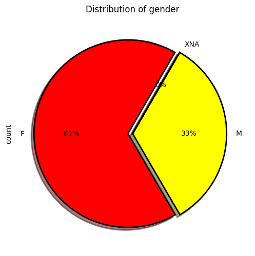

```python
fig = plt.figure(figsize=(13,6))
plt.subplot(121)
app_data['CODE_GENDER'].value_counts().plot.pie(autopct = '%1.0f%%' , colors=['red','yellow'],startangle = 60, wedgeprops={"linewidth":2 , "edgecolor":"k"},explode=[.05,0,0], shadow=True)
plt.title("Distribution of gender")
plt.show()
```

the pie chart shows a clear female bias in the dataset

Univariate Analysis

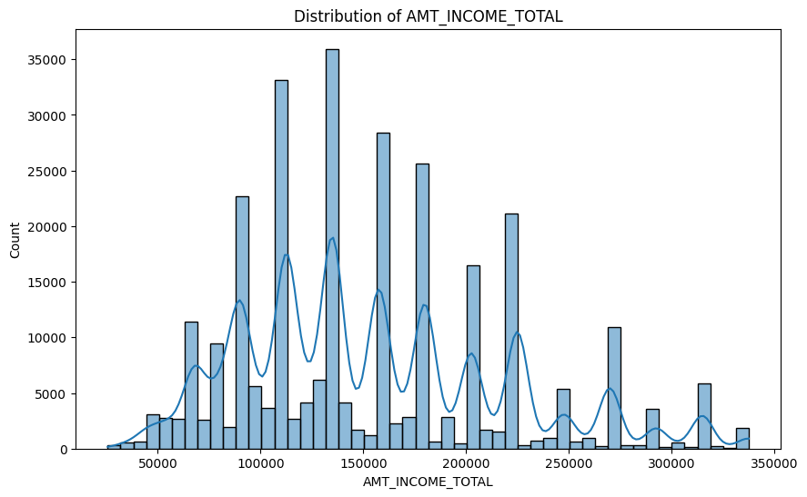

```python
plt.figure(figsize=(10, 6))
sns.histplot(app_data['AMT_INCOME_TOTAL'], bins=50, kde=True)
plt.title('Distribution of AMT_INCOME_TOTAL')
plt.show()
```

the graph shows that most individuals in the dataset have relatively low incomes, with a smaller number of individuals reporting higher incomes.

### Categorical Features Analysis

### Distribution of loan types by default status.

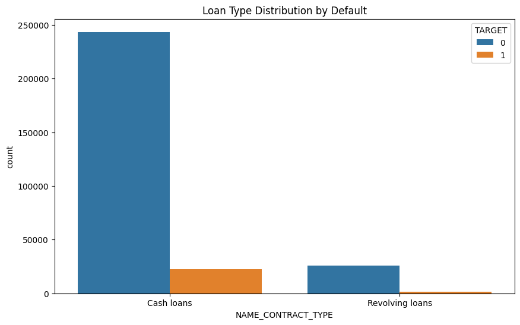

```python
plt.figure(figsize=(10, 6))
sns.countplot(data=app_data, x='NAME_CONTRACT_TYPE', hue='TARGET')
plt.title('Loan Type Distribution by Default')
plt.show()
```

the chart shows that "Cash loans" are the most popular loan type, but both types have a certain level of default risk.

### Bivariate Analysis

#### Distribution of AMT_CREDIT (loan amount) for borrowers who defaulted (TARGET=1) and those who did not default (TARGET=0)

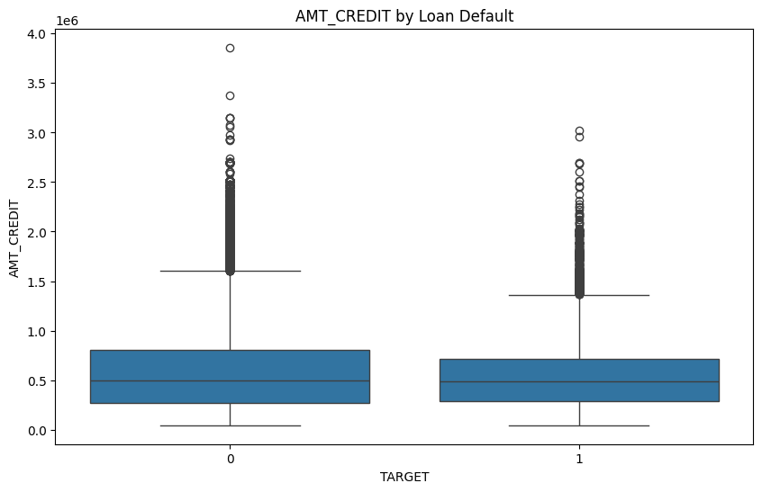

```python
plt.figure(figsize=(10, 6))
sns.boxplot(data=app_data, x='TARGET', y='AMT_CREDIT')
plt.title('AMT_CREDIT by Loan Default')
plt.show()
```

Distribution of Target Variable

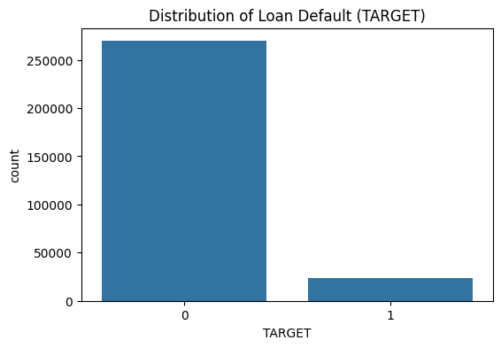

```python
# Plot distribution of the target variable
plt.figure(figsize=(6, 4))
sns.countplot(data=app_data, x='TARGET')
plt.title('Distribution of Loan Default (TARGET)')
plt.show()
```

the chart shows that the dataset is imbalanced, with a clear majority of loans being repaid.

### Correlation Heatmap

#### Displays the correlation between each numeric feature in my dataset and the TARGET variable

1. 1: Perfect positive correlation (both variables move in the same direction).
2. -1: Perfect negative correlation (one variable increases as the other decreases).
3. 0: No correlation (no linear relationship between the variables).

```python
# Drop non-numeric columns from the DataFrame
numeric_data = app_data.select_dtypes(include=[np.number])

# Check if 'TARGET' is included and drop if not numeric
if 'TARGET' not in numeric_data.columns:
    print("'TARGET' column is not numeric. Please convert or exclude it from correlation analysis.")
else:
    # Calculate correlations with the target variable
    correlation = numeric_data.corr()['TARGET'].sort_values(ascending=False)
    print("Correlation with TARGET:")
    print(correlation)


# The corr() function calculates the Pearson correlation coefficient, which measures linear relationships between variables.
```

```
Correlation with TARGET:
TARGET                         1.000000
DAYS_BIRTH                     0.078812
REGION_RATING_CLIENT           0.065855
REGION_RATING_CLIENT_W_CITY    0.065388
DAYS_LAST_PHONE_CHANGE         0.056880
                                 ...
AMT_GOODS_PRICE               -0.041081
REGION_POPULATION_RELATIVE    -0.041597
EXT_SOURCE_1                  -0.098731
EXT_SOURCE_3                  -0.155721
EXT_SOURCE_2                  -0.159631
Name: TARGET, Length: 106, dtype: float64
```

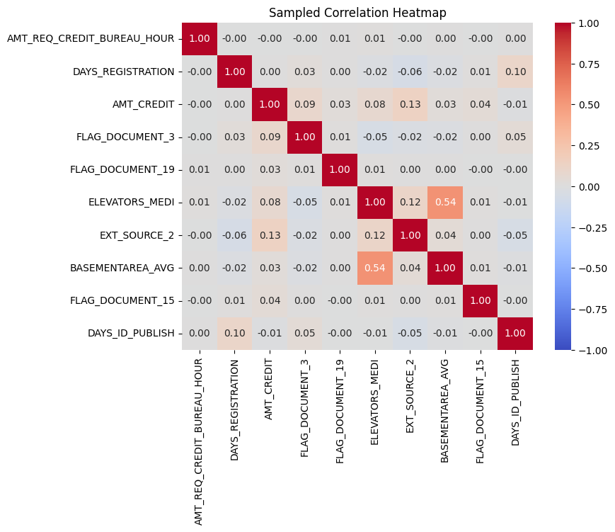

```python
import seaborn as sns
import matplotlib.pyplot as plt

# Sample 10 random columns from the numeric data for a smaller heatmap
sampled_data = numeric_data.sample(n=10, axis=1, random_state=42)

# Calculate correlations
correlation_matrix_sample = sampled_data.corr()

# Plot heatmap
plt.figure(figsize=(8, 6))
sns.heatmap(correlation_matrix_sample, annot=True, cmap='coolwarm', fmt=".2f", vmin=-1, vmax=1)
plt.title('Sampled Correlation Heatmap')
plt.show()
```

Categorical Feature Analysis:

1. For categorical features, analyze the distribution of categories and their relation to the target variable.

[figure not shown]

[figure not shown]

```python
import matplotlib.pyplot as plt
import seaborn as sns

# List of selected categorical features to plot
selected_features = ['CODE_GENDER', 'NAME_CONTRACT_TYPE']

# Loop through the selected features and plot
for feature in selected_features:
    plt.figure(figsize=(10, 5))
    sns.countplot(data=app_data, x=feature, hue='TARGET')
    plt.title(f'Distribution of {feature} by Loan Default')
    plt.xticks(rotation=90)
    plt.show()
```

Distribution of Key Numeric Features:

[figure not shown]

```python
import matplotlib.pyplot as plt
import seaborn as sns

# Define the selected numerical features to plot
selected_numerical_features = ['AMT_INCOME_TOTAL', 'AMT_CREDIT']

# Create subplots
plt.figure(figsize=(15, 5 * len(selected_numerical_features)))
for i, feature in enumerate(selected_numerical_features):
    plt.subplot(len(selected_numerical_features), 1, i + 1)
    sns.histplot(data=app_data, x=feature, bins=30, kde=True)
    plt.title(f'Distribution of {feature}')
    plt.xlabel('')
    plt.ylabel('')

plt.tight_layout()
plt.show()
```

Note:

1. Positive Skewness: Values greater than 0 indicate a right skew. The distribution's tail on the right side is longer or more spread out.
2. Negative Skewness: Values less than 0 indicate a left skew. The distribution's tail on the left side is longer or more spread out.
3. Zero Skewness: A skewness value close to 0 suggests a symmetrical distribution, although it may not be perfectly normal.

Both AMT_INCOME_TOTAL and AMT_CREDIT have right-skewed distributions with a few outliers. This suggests that a significant proportion of individuals have relatively low incomes and loan amounts, while a smaller number have much higher incomes and loan amounts.

# Prev_App_Data

Null values plot

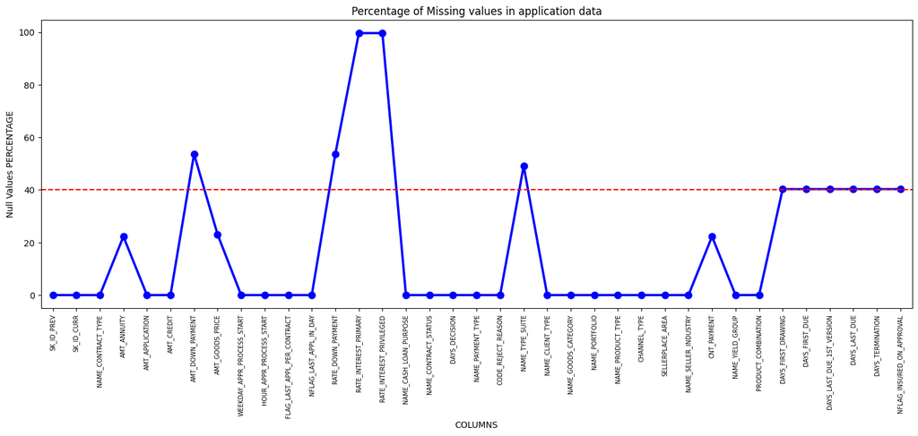

```python
null_prev_app = pd.DataFrame((prev_app_data.isnull().sum())*100/prev_app_data.shape[0]).reset_index()
null_prev_app.columns = ['column_name' , 'null_value_percentage']

fig = plt.figure(figsize=(18,6))
ax = sns.pointplot(x="column_name" , y="null_value_percentage" , data = null_prev_app , color='blue')
plt.xticks(rotation=90,fontsize=7)
ax.axhline(40, ls='--',color='red')
plt.title("Percentage of Missing values in application data")
plt.ylabel("Null Values PERCENTAGE")
plt.xlabel("COLUMNS")
plt.show()
```

```python
null_prev_app_40 = null_prev_app[null_prev_app['null_value_percentage'] > 40]
null_prev_app_40
```

|  | column_name | null_value_percentage |
| --- | --- | --- |
| 6 | AMT_DOWN_PAYMENT | 53.636480 |
| 12 | RATE_DOWN_PAYMENT | 53.636480 |
| 13 | RATE_INTEREST_PRIMARY | 99.643698 |
| 14 | RATE_INTEREST_PRIVILEGED | 99.643698 |
| 20 | NAME_TYPE_SUITE | 49.119754 |
| 31 | DAYS_FIRST_DRAWING | 40.298129 |
| 32 | DAYS_FIRST_DUE | 40.298129 |
| 33 | DAYS_LAST_DUE_1ST_VERSION | 40.298129 |
| 34 | DAYS_LAST_DUE | 40.298129 |
| 35 | DAYS_TERMINATION | 40.298129 |
| 36 | NFLAG_INSURED_ON_APPROVAL | 40.298129 |

### Distributions of three numeric features: AMT_GOODS_PRICE, AMT_ANNUITY, and CNT_PAYMENT.

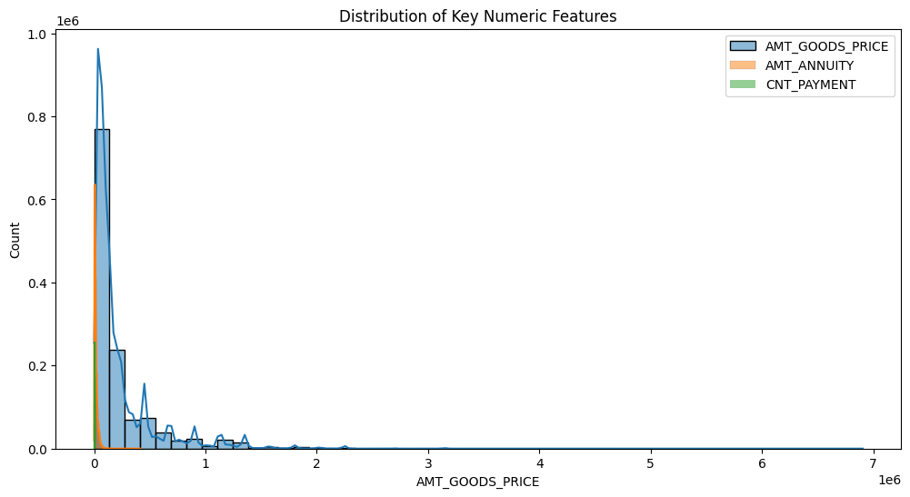

```python
# Plot distribution of key numeric features
key_numeric_features = ['AMT_GOODS_PRICE', 'AMT_ANNUITY', 'CNT_PAYMENT']  # Example features
plt.figure(figsize=(12, 6))
for feature in key_numeric_features:
    sns.histplot(data=prev_app_data, x=feature, bins=50, kde=True, label=feature)
plt.title('Distribution of Key Numeric Features')
plt.legend()
plt.show()
```

All three features exhibit right-skewed distributions, indicating that a few individuals have extreme values, while the majority of individuals have values closer to the median.

### Categorical Feature Distribution:

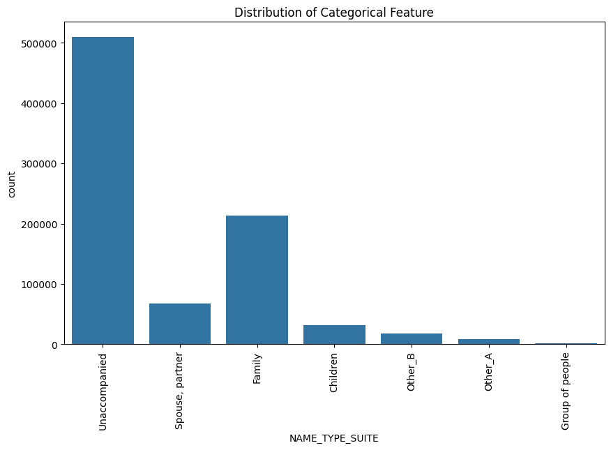

```python
# Plot distribution of a categorical feature
plt.figure(figsize=(10, 6))
sns.countplot(data=prev_app_data, x='NAME_TYPE_SUITE')
plt.title('Distribution of Categorical Feature')
plt.xticks(rotation=90)
plt.show()
```

the chart shows that the majority of individuals in the dataset are not accompanied by anyone, while a much smaller number are accompanied by spouses, partners, family, or others.

### Basic Scatter Plots for Key Relationships:

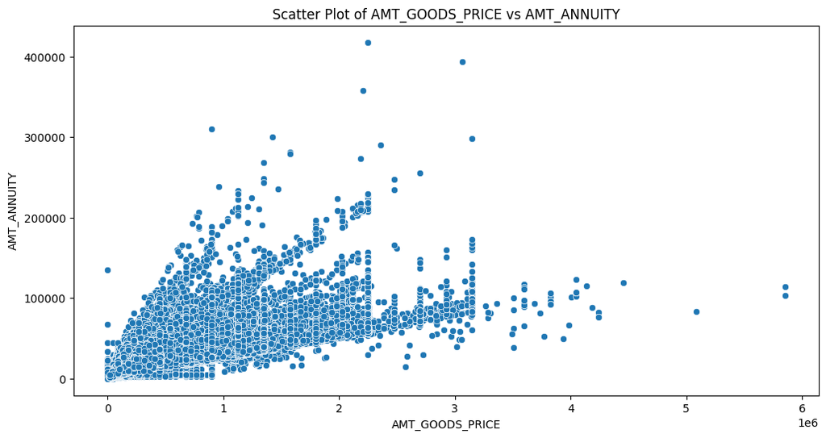

```python
# Plot scatter plots for key relationships
plt.figure(figsize=(12, 6))
sns.scatterplot(data=prev_app_data, x='AMT_GOODS_PRICE', y='AMT_ANNUITY')
plt.title('Scatter Plot of AMT_GOODS_PRICE vs AMT_ANNUITY')
plt.show()
```

the plot suggests that there is a strong positive relationship between the price of goods purchased and the annuity payment required.

# Data Preprocessing:

## Converting negative values to positive

helps in making the data more understandable, consistent, and easier to process for analysis and modeling.

```python
app_data['DAYS_BIRTH'] = abs(app_data['DAYS_BIRTH'])
app_data['DAYS_ID_PUBLISH'] = abs(app_data['DAYS_ID_PUBLISH'])
app_data['DAYS_ID_PUBLISH'] = abs(app_data['DAYS_ID_PUBLISH'])
app_data['DAYS_LAST_PHONE_CHANGE'] = abs(app_data['DAYS_LAST_PHONE_CHANGE'])
```

```python
app_data.head()
```

|  | SK_ID_CURR | TARGET | NAME_CONTRACT_TYPE | CODE_GENDER | FLAG_OWN_CAR | FLAG_OWN_REALTY | CNT_CHILDREN | AMT_INCOME_TOTAL | AMT_CREDIT | AMT_ANNUITY | ... | FLAG_DOCUMENT_18 | FLAG_DOCUMENT_19 | FLAG_DOCUMENT_20 | FLAG_DOCUMENT_21 | AMT_REQ_CREDIT_BUREAU_HOUR | AMT_REQ_CREDIT_BUREAU_DAY | AMT_REQ_CREDIT_BUREAU_WEEK | AMT_REQ_CREDIT_BUREAU_MON | AMT_REQ_CREDIT_BUREAU_QRT | AMT_REQ_CREDIT_BUREAU_YEAR |
| --- | --- | --- | --- | --- | --- | --- | --- | --- | --- | --- | --- | --- | --- | --- | --- | --- | --- | --- | --- | --- | --- |
| 0 | 100002 | 1 | Cash loans | M | N | Y | 0 | 202500.0 | 406597.5 | 24700.5 | ... | 0 | 0 | 0 | 0 | 0.0 | 0.0 | 0.0 | 0.0 | 0.0 | 1.0 |
| 1 | 100003 | 0 | Cash loans | F | N | N | 0 | 270000.0 | 1293502.5 | 35698.5 | ... | 0 | 0 | 0 | 0 | 0.0 | 0.0 | 0.0 | 0.0 | 0.0 | 0.0 |
| 2 | 100004 | 0 | Revolving loans | M | Y | Y | 0 | 67500.0 | 135000.0 | 6750.0 | ... | 0 | 0 | 0 | 0 | 0.0 | 0.0 | 0.0 | 0.0 | 0.0 | 0.0 |
| 3 | 100006 | 0 | Cash loans | F | N | Y | 0 | 135000.0 | 312682.5 | 29686.5 | ... | 0 | 0 | 0 | 0 | NaN | NaN | NaN | NaN | NaN | NaN |
| 4 | 100007 | 0 | Cash loans | M | N | Y | 0 | 121500.0 | 513000.0 | 21865.5 | ... | 0 | 0 | 0 | 0 | 0.0 | 0.0 | 0.0 | 0.0 | 0.0 | 0.0 |

5 rows × 122 columns

```python
app_data['DAYS_BIRTH'].head()
```

|  | DAYS_BIRTH |
| --- | --- |
| 0 | 9461 |
| 1 | 16765 |
| 2 | 19046 |
| 3 | 19005 |
| 4 | 19932 |

**dtype:** int64

## Seperating numerical & categorical variables in application data

```python
app_data.dtypes
```

|  | 0 |
| --- | --- |
| SK_ID_CURR | int64 |
| TARGET | int64 |
| NAME_CONTRACT_TYPE | object |
| CODE_GENDER | object |
| FLAG_OWN_CAR | object |
| ... | ... |
| AMT_REQ_CREDIT_BUREAU_DAY | float64 |
| AMT_REQ_CREDIT_BUREAU_WEEK | float64 |
| AMT_REQ_CREDIT_BUREAU_MON | float64 |
| AMT_REQ_CREDIT_BUREAU_QRT | float64 |
| AMT_REQ_CREDIT_BUREAU_YEAR | float64 |

122 rows × 1 columns

**dtype:** object

```python
obj_dtypes= [i for i in app_data.select_dtypes(include=object).columns]
obj_dtypes
```

```
['NAME_CONTRACT_TYPE',
 'CODE_GENDER',
 'FLAG_OWN_CAR',
 'FLAG_OWN_REALTY',
 'NAME_TYPE_SUITE',
 'NAME_INCOME_TYPE',
 'NAME_EDUCATION_TYPE',
 'NAME_FAMILY_STATUS',
 'NAME_HOUSING_TYPE',
 'OCCUPATION_TYPE',
 'WEEKDAY_APPR_PROCESS_START',
 'ORGANIZATION_TYPE',
 'FONDKAPREMONT_MODE',
 'HOUSETYPE_MODE',
 'WALLSMATERIAL_MODE',
 'EMERGENCYSTATE_MODE']
```

```python
num_dtypes = [ i for i in app_data.select_dtypes(include='number').columns]
num_dtypes
```

```
['SK_ID_CURR',
 'TARGET',
 'CNT_CHILDREN',
 'AMT_INCOME_TOTAL',
 'AMT_CREDIT',
 'AMT_ANNUITY',
 'AMT_GOODS_PRICE',
 'REGION_POPULATION_RELATIVE',
 'DAYS_BIRTH',
 'DAYS_EMPLOYED',
 'DAYS_REGISTRATION',
 'DAYS_ID_PUBLISH',
 'OWN_CAR_AGE',
 'FLAG_MOBIL',
 'FLAG_EMP_PHONE',
 'FLAG_WORK_PHONE',
 'FLAG_CONT_MOBILE',
 'FLAG_PHONE',
 'FLAG_EMAIL',
 'CNT_FAM_MEMBERS',
 'REGION_RATING_CLIENT',
 'REGION_RATING_CLIENT_W_CITY',
 'HOUR_APPR_PROCESS_START',
 'REG_REGION_NOT_LIVE_REGION',
 'REG_REGION_NOT_WORK_REGION',
 'LIVE_REGION_NOT_WORK_REGION',
 'REG_CITY_NOT_LIVE_CITY',
 'REG_CITY_NOT_WORK_CITY',
 'LIVE_CITY_NOT_WORK_CITY',
 'EXT_SOURCE_1',
 'EXT_SOURCE_2',
 'EXT_SOURCE_3',
 'APARTMENTS_AVG',
 'BASEMENTAREA_AVG',
 'YEARS_BEGINEXPLUATATION_AVG',
 'YEARS_BUILD_AVG',
 'COMMONAREA_AVG',
 'ELEVATORS_AVG',
 'ENTRANCES_AVG',
 'FLOORSMAX_AVG',
```

[output cut: 51 more lines]

```
 'FLAG_DOCUMENT_13',
 'FLAG_DOCUMENT_14',
 'FLAG_DOCUMENT_15',
 'FLAG_DOCUMENT_16',
 'FLAG_DOCUMENT_17',
 'FLAG_DOCUMENT_18',
 'FLAG_DOCUMENT_19',
 'FLAG_DOCUMENT_20',
 'FLAG_DOCUMENT_21',
 'AMT_REQ_CREDIT_BUREAU_HOUR',
 'AMT_REQ_CREDIT_BUREAU_DAY',
 'AMT_REQ_CREDIT_BUREAU_WEEK',
 'AMT_REQ_CREDIT_BUREAU_MON',
 'AMT_REQ_CREDIT_BUREAU_QRT',
 'AMT_REQ_CREDIT_BUREAU_YEAR']
```

## Concatenating application data and previous application data

```python
import pandas as pd
# Load the datasets
app_data = pd.read_csv('/content/application_data.csv')
prev_app_data = pd.read_csv('/content/previous_application.csv')
```

```python
print("Missing values in application data:\n", app_data.isnull().sum())
print("Missing values in previous application data:\n", prev_app_data.isnull().sum())
```

```
Missing values in application data:
 SK_ID_CURR                        0
TARGET                            0
NAME_CONTRACT_TYPE                0
CODE_GENDER                       0
FLAG_OWN_CAR                      0
                              ...
AMT_REQ_CREDIT_BUREAU_DAY     41519
AMT_REQ_CREDIT_BUREAU_WEEK    41519
AMT_REQ_CREDIT_BUREAU_MON     41519
AMT_REQ_CREDIT_BUREAU_QRT     41519
AMT_REQ_CREDIT_BUREAU_YEAR    41519
Length: 122, dtype: int64
Missing values in previous application data:
 SK_ID_PREV                           0
SK_ID_CURR                           0
NAME_CONTRACT_TYPE                   0
AMT_ANNUITY                     372235
AMT_APPLICATION                      0
AMT_CREDIT                           1
AMT_DOWN_PAYMENT                895844
AMT_GOODS_PRICE                 385515
WEEKDAY_APPR_PROCESS_START           0
HOUR_APPR_PROCESS_START              0
FLAG_LAST_APPL_PER_CONTRACT          0
NFLAG_LAST_APPL_IN_DAY               0
RATE_DOWN_PAYMENT               895844
RATE_INTEREST_PRIMARY          1664263
RATE_INTEREST_PRIVILEGED       1664263
NAME_CASH_LOAN_PURPOSE               0
NAME_CONTRACT_STATUS                 0
DAYS_DECISION                        0
NAME_PAYMENT_TYPE                    0
CODE_REJECT_REASON                   0
NAME_TYPE_SUITE                 820405
NAME_CLIENT_TYPE                     0
NAME_GOODS_CATEGORY                  0
NAME_PORTFOLIO                       0
NAME_PRODUCT_TYPE                    0
CHANNEL_TYPE                         0
SELLERPLACE_AREA                     0
NAME_SELLER_INDUSTRY                 0
CNT_PAYMENT                     372230
NAME_YIELD_GROUP                     0
PRODUCT_COMBINATION                346
DAYS_FIRST_DRAWING              673065
DAYS_FIRST_DUE                  673065
DAYS_LAST_DUE_1ST_VERSION       673065
DAYS_LAST_DUE                   673065
DAYS_TERMINATION                673065
NFLAG_INSURED_ON_APPROVAL       673065
dtype: int64
```

```python
from sklearn.impute import SimpleImputer

# Separate numerical and categorical columns
num_features = app_data.select_dtypes(include=['float64', 'int64']).columns
cat_features = app_data.select_dtypes(include=['object']).columns

# Numerical features imputation
num_imputer = SimpleImputer(strategy='median')
app_data[num_features] = num_imputer.fit_transform(app_data[num_features])

# Categorical features imputation
cat_imputer = SimpleImputer(strategy='most_frequent')
app_data[cat_features] = cat_imputer.fit_transform(app_data[cat_features])

# Check missing values again
print("Missing values in application data after imputation:\n", app_data.isnull().sum())
```

```
Missing values in application data after imputation:
 SK_ID_CURR                    0
TARGET                        0
NAME_CONTRACT_TYPE            0
CODE_GENDER                   0
FLAG_OWN_CAR                  0
                             ..
AMT_REQ_CREDIT_BUREAU_DAY     0
AMT_REQ_CREDIT_BUREAU_WEEK    0
AMT_REQ_CREDIT_BUREAU_MON     0
AMT_REQ_CREDIT_BUREAU_QRT     0
AMT_REQ_CREDIT_BUREAU_YEAR    0
Length: 122, dtype: int64
```

```python
# Separate numerical and categorical columns
num_features_prev = prev_app_data.select_dtypes(include=['float64', 'int64']).columns
cat_features_prev = prev_app_data.select_dtypes(include=['object']).columns

# Numerical features imputation
num_imputer_prev = SimpleImputer(strategy='median')
prev_app_data[num_features_prev] = num_imputer_prev.fit_transform(prev_app_data[num_features_prev])

# Categorical features imputation
cat_imputer_prev = SimpleImputer(strategy='most_frequent')
prev_app_data[cat_features_prev] = cat_imputer_prev.fit_transform(prev_app_data[cat_features_prev])

# Check missing values again
print("Missing values in previous application data after imputation:\n", prev_app_data.isnull().sum())
```

```
Missing values in previous application data after imputation:
 SK_ID_PREV                     0
SK_ID_CURR                     0
NAME_CONTRACT_TYPE             0
AMT_ANNUITY                    0
AMT_APPLICATION                0
AMT_CREDIT                     0
AMT_DOWN_PAYMENT               0
AMT_GOODS_PRICE                0
WEEKDAY_APPR_PROCESS_START     0
HOUR_APPR_PROCESS_START        0
FLAG_LAST_APPL_PER_CONTRACT    0
NFLAG_LAST_APPL_IN_DAY         0
RATE_DOWN_PAYMENT              0
RATE_INTEREST_PRIMARY          0
RATE_INTEREST_PRIVILEGED       0
NAME_CASH_LOAN_PURPOSE         0
NAME_CONTRACT_STATUS           0
DAYS_DECISION                  0
NAME_PAYMENT_TYPE              0
CODE_REJECT_REASON             0
NAME_TYPE_SUITE                0
NAME_CLIENT_TYPE               0
NAME_GOODS_CATEGORY            0
NAME_PORTFOLIO                 0
NAME_PRODUCT_TYPE              0
CHANNEL_TYPE                   0
SELLERPLACE_AREA               0
NAME_SELLER_INDUSTRY           0
CNT_PAYMENT                    0
NAME_YIELD_GROUP               0
PRODUCT_COMBINATION            0
DAYS_FIRST_DRAWING             0
DAYS_FIRST_DUE                 0
DAYS_LAST_DUE_1ST_VERSION      0
DAYS_LAST_DUE                  0
DAYS_TERMINATION               0
NFLAG_INSURED_ON_APPROVAL      0
dtype: int64
```

```python
# Prepare the data, ensuring 'TARGET' is not dropped
app_data_x = app_data.copy()
prev_app_x = prev_app_data.copy()
```

This creates deep copies of the app_data and prev_app_data DataFrames. The purpose of creating copies is to ensure that the original data remains unchanged while you perform further processing on these copies.

```python
# Add a column to indicate the source of the data
app_data_x["type"] = 'app_data'
prev_app_x["type"] = 'prev_app_data'
```

Adding a type column to indicate the source of the data helps keep track of the origin of each record, making it easier to manage, analyze, and debug datasets, especially when combining multiple sources.

```python
# Concatenate the datasets
data = pd.concat([app_data_x, prev_app_x], axis=0, ignore_index=True)
# starting from 0, which avoids index duplication from the original DataFrames.

# Print the first few rows and the shape of the concatenated dataset to verify
print("Concatenated Dataset")
print(data.head())
print(f"Shape of the concatenated dataset: {data.shape}")
```

```
Concatenated Dataset
   SK_ID_CURR  TARGET NAME_CONTRACT_TYPE CODE_GENDER FLAG_OWN_CAR  \
0    100002.0     1.0         Cash loans           M            N
1    100003.0     0.0         Cash loans           F            N
2    100004.0     0.0    Revolving loans           M            Y
3    100006.0     0.0         Cash loans           F            N
4    100007.0     0.0         Cash loans           M            N

  FLAG_OWN_REALTY  CNT_CHILDREN  AMT_INCOME_TOTAL  AMT_CREDIT  AMT_ANNUITY  \
0               Y           0.0          202500.0    406597.5      24700.5
1               N           0.0          270000.0   1293502.5      35698.5
2               Y           0.0           67500.0    135000.0       6750.0
3               Y           0.0          135000.0    312682.5      29686.5
4               Y           0.0          121500.0    513000.0      21865.5

   ...  NAME_SELLER_INDUSTRY CNT_PAYMENT NAME_YIELD_GROUP PRODUCT_COMBINATION  \
0  ...                   NaN         NaN              NaN                 NaN
1  ...                   NaN         NaN              NaN                 NaN
2  ...                   NaN         NaN              NaN                 NaN
3  ...                   NaN         NaN              NaN                 NaN
4  ...                   NaN         NaN              NaN                 NaN

  DAYS_FIRST_DRAWING DAYS_FIRST_DUE  DAYS_LAST_DUE_1ST_VERSION  DAYS_LAST_DUE  \
0                NaN            NaN                        NaN            NaN
1                NaN            NaN                        NaN            NaN
2                NaN            NaN                        NaN            NaN
3                NaN            NaN                        NaN            NaN
4                NaN            NaN                        NaN            NaN

   DAYS_TERMINATION  NFLAG_INSURED_ON_APPROVAL
0               NaN                        NaN
1               NaN                        NaN
2               NaN                        NaN
3               NaN                        NaN
4               NaN                        NaN

[5 rows x 152 columns]
Shape of the concatenated dataset: (1977725, 152)
```

```python
import pandas as pd

# Sample dataset information
data_summary = {
    'Dataset': ['Application Data', 'Previous Data', 'Concatenated Data'],
    'Shape': [app_data_x.shape, prev_app_x.shape, data.shape],
    'Examples': [
        'SK_ID_CURR, TARGET, AMT_INCOME_TOTAL, AMT_CREDIT',
        'SK_ID_PREV, AMT_APPLICATION, AMT_CREDIT',
        'Merged columns from both datasets'
    ]
}

# Create DataFrame
df_summary = pd.DataFrame(data_summary)

# Display the DataFrame
print(df_summary)
# Optionally, save to a CSV file
# df_summary.to_csv('data_summary.csv', index=False)
```

```
             Dataset           Shape  \
0   Application Data   (307511, 123)
1      Previous Data   (1670214, 38)
2  Concatenated Data  (1977725, 152)

                                           Examples
0  SK_ID_CURR, TARGET, AMT_INCOME_TOTAL, AMT_CREDIT
1           SK_ID_PREV, AMT_APPLICATION, AMT_CREDIT
2                 Merged columns from both datasets
```

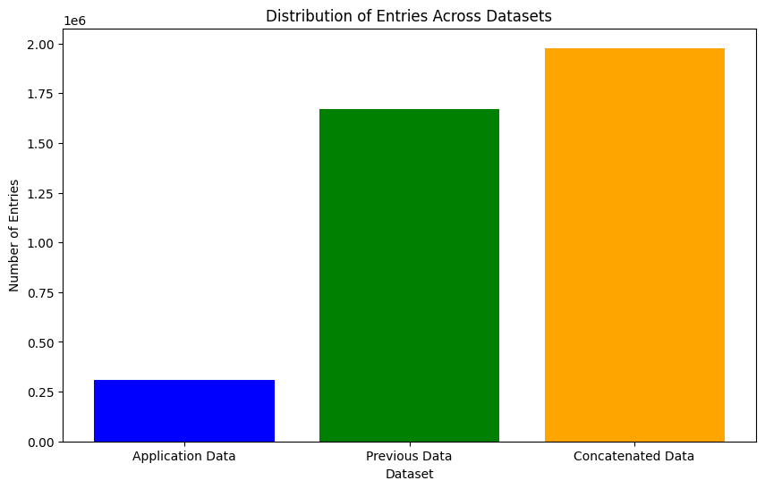

```python
import matplotlib.pyplot as plt

# Number of entries for each dataset
dataset_names = ['Application Data', 'Previous Data', 'Concatenated Data']
dataset_sizes = [app_data_x.shape[0], prev_app_x.shape[0], data.shape[0]]

# Create a bar plot
plt.figure(figsize=(10, 6))
plt.bar(dataset_names, dataset_sizes, color=['blue', 'green', 'orange'])
plt.xlabel('Dataset')
plt.ylabel('Number of Entries')
plt.title('Distribution of Entries Across Datasets')
plt.show()
```

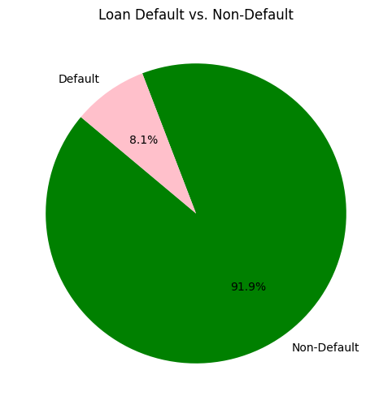

```python
import matplotlib.pyplot as plt


default_counts = data['TARGET'].value_counts()

# Labels and sizes
labels = ['Non-Default', 'Default']
sizes = default_counts.sort_index()

# Plot
plt.figure(figsize=(8, 6))
plt.pie(sizes, labels=labels, autopct='%1.1f%%', startangle=140, colors=['green', 'pink'])
plt.title('Loan Default vs. Non-Default')
plt.show()
```

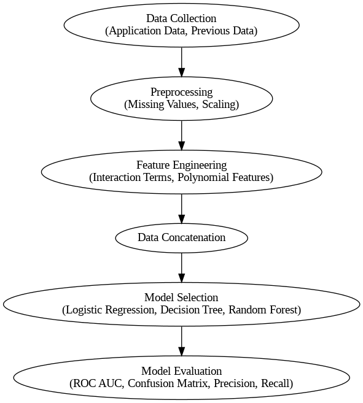

```python
from graphviz import Digraph

# Create a new directed graph
dot = Digraph(comment='Credit Risk Assessment Pipeline')

# Define the nodes for each step in the pipeline
dot.node('A', 'Data Collection\n(Application Data, Previous Data)')
dot.node('B', 'Preprocessing\n(Missing Values, Scaling)')
dot.node('C', 'Feature Engineering\n(Interaction Terms, Polynomial Features)')
dot.node('D', 'Data Concatenation')
dot.node('E', 'Model Selection\n(Logistic Regression, Decision Tree, Random Forest)')
dot.node('F', 'Model Evaluation\n(ROC AUC, Confusion Matrix, Precision, Recall)')

# Define the edges to show the flow of the pipeline
dot.edges(['AB', 'BC', 'CD', 'DE', 'EF'])

# Render the flowchart to a file or display it
dot.render('credit_risk_assessment_pipeline', format='png', cleanup=False)

# To display in Jupyter Notebook (optional)
from IPython.display import Image
Image(filename='credit_risk_assessment_pipeline.png')
```

```python
data.shape
```

[output not shown]

```python
data.head()
```

|  | SK_ID_CURR | TARGET | NAME_CONTRACT_TYPE | CODE_GENDER | FLAG_OWN_CAR | FLAG_OWN_REALTY | CNT_CHILDREN | AMT_INCOME_TOTAL | AMT_CREDIT | AMT_ANNUITY | ... | NAME_SELLER_INDUSTRY | CNT_PAYMENT | NAME_YIELD_GROUP | PRODUCT_COMBINATION | DAYS_FIRST_DRAWING | DAYS_FIRST_DUE | DAYS_LAST_DUE_1ST_VERSION | DAYS_LAST_DUE | DAYS_TERMINATION | NFLAG_INSURED_ON_APPROVAL |
| --- | --- | --- | --- | --- | --- | --- | --- | --- | --- | --- | --- | --- | --- | --- | --- | --- | --- | --- | --- | --- | --- |
| 0 | 100002.0 | 1.0 | Cash loans | M | N | Y | 0.0 | 202500.0 | 406597.5 | 24700.5 | ... | NaN | NaN | NaN | NaN | NaN | NaN | NaN | NaN | NaN | NaN |
| 1 | 100003.0 | 0.0 | Cash loans | F | N | N | 0.0 | 270000.0 | 1293502.5 | 35698.5 | ... | NaN | NaN | NaN | NaN | NaN | NaN | NaN | NaN | NaN | NaN |
| 2 | 100004.0 | 0.0 | Revolving loans | M | Y | Y | 0.0 | 67500.0 | 135000.0 | 6750.0 | ... | NaN | NaN | NaN | NaN | NaN | NaN | NaN | NaN | NaN | NaN |
| 3 | 100006.0 | 0.0 | Cash loans | F | N | Y | 0.0 | 135000.0 | 312682.5 | 29686.5 | ... | NaN | NaN | NaN | NaN | NaN | NaN | NaN | NaN | NaN | NaN |
| 4 | 100007.0 | 0.0 | Cash loans | M | N | Y | 0.0 | 121500.0 | 513000.0 | 21865.5 | ... | NaN | NaN | NaN | NaN | NaN | NaN | NaN | NaN | NaN | NaN |

5 rows × 152 columns

## Handle Missing Values after concat:

```python
missing_values_data = data.isnull().sum()
print(missing_values_data.to_string())
```

```
SK_ID_CURR                           0
TARGET                          136677
NAME_CONTRACT_TYPE                   0
CODE_GENDER                     136677
FLAG_OWN_CAR                    136677
FLAG_OWN_REALTY                 136677
CNT_CHILDREN                    136677
AMT_INCOME_TOTAL                136677
AMT_CREDIT                           0
AMT_ANNUITY                          0
AMT_GOODS_PRICE                      0
NAME_TYPE_SUITE                      0
NAME_INCOME_TYPE                136677
NAME_EDUCATION_TYPE             136677
NAME_FAMILY_STATUS              136677
NAME_HOUSING_TYPE               136677
REGION_POPULATION_RELATIVE      136677
DAYS_BIRTH                      136677
DAYS_EMPLOYED                   136677
DAYS_REGISTRATION               136677
DAYS_ID_PUBLISH                 136677
OWN_CAR_AGE                     136677
FLAG_MOBIL                      136677
FLAG_EMP_PHONE                  136677
FLAG_WORK_PHONE                 136677
FLAG_CONT_MOBILE                136677
FLAG_PHONE                      136677
FLAG_EMAIL                      136677
OCCUPATION_TYPE                 136677
CNT_FAM_MEMBERS                 136677
REGION_RATING_CLIENT            136677
REGION_RATING_CLIENT_W_CITY     136677
WEEKDAY_APPR_PROCESS_START           0
HOUR_APPR_PROCESS_START              0
REG_REGION_NOT_LIVE_REGION      136677
REG_REGION_NOT_WORK_REGION      136677
LIVE_REGION_NOT_WORK_REGION     136677
REG_CITY_NOT_LIVE_CITY          136677
REG_CITY_NOT_WORK_CITY          136677
LIVE_CITY_NOT_WORK_CITY         136677
```

[output cut: 97 more lines]

```
NAME_GOODS_CATEGORY              60162
NAME_PORTFOLIO                   60162
NAME_PRODUCT_TYPE                60162
CHANNEL_TYPE                     60162
SELLERPLACE_AREA                 60162
NAME_SELLER_INDUSTRY             60162
CNT_PAYMENT                      60162
NAME_YIELD_GROUP                 60162
PRODUCT_COMBINATION              60162
DAYS_FIRST_DRAWING               60162
DAYS_FIRST_DUE                   60162
DAYS_LAST_DUE_1ST_VERSION        60162
DAYS_LAST_DUE                    60162
DAYS_TERMINATION                 60162
NFLAG_INSURED_ON_APPROVAL        60162
```

```python
missing_values = pd.DataFrame(data.isnull().sum().sort_values(ascending=False)).reset_index()
missing_values.rename(columns={'index': 'feature', 0: 'missing_count'}, inplace=True)
missing_values.head(20)
```

|  | feature | missing_count |
| --- | --- | --- |
| 0 | AMT_REQ_CREDIT_BUREAU_QRT | 136677 |
| 1 | AMT_REQ_CREDIT_BUREAU_YEAR | 136677 |
| 2 | NAME_INCOME_TYPE | 136677 |
| 3 | NAME_EDUCATION_TYPE | 136677 |
| 4 | NAME_FAMILY_STATUS | 136677 |
| 5 | NAME_HOUSING_TYPE | 136677 |
| 6 | FLAG_DOCUMENT_18 | 136677 |
| 7 | FLAG_DOCUMENT_19 | 136677 |
| 8 | FLAG_DOCUMENT_20 | 136677 |
| 9 | FLAG_DOCUMENT_21 | 136677 |
| 10 | AMT_REQ_CREDIT_BUREAU_HOUR | 136677 |
| 11 | AMT_REQ_CREDIT_BUREAU_DAY | 136677 |
| 12 | AMT_REQ_CREDIT_BUREAU_WEEK | 136677 |
| 13 | AMT_REQ_CREDIT_BUREAU_MON | 136677 |
| 14 | REGION_POPULATION_RELATIVE | 136677 |
| 15 | DAYS_BIRTH | 136677 |
| 16 | DAYS_EMPLOYED | 136677 |
| 17 | DAYS_REGISTRATION | 136677 |
| 18 | DAYS_ID_PUBLISH | 136677 |
| 19 | OWN_CAR_AGE | 136677 |

```python
missing_values['missing_percent'] = (missing_values['missing_count'] / len(data) * 100).sort_values(ascending=False)

print(missing_values.to_string())
```

```
                          feature  missing_count  missing_percent
0       AMT_REQ_CREDIT_BUREAU_QRT         136677        69.435935
1      AMT_REQ_CREDIT_BUREAU_YEAR         136677        69.435935
2                NAME_INCOME_TYPE         136677        69.435935
3             NAME_EDUCATION_TYPE         136677        69.435935
4              NAME_FAMILY_STATUS         136677        69.435935
5               NAME_HOUSING_TYPE         136677        69.435935
6                FLAG_DOCUMENT_18         136677        69.435935
7                FLAG_DOCUMENT_19         136677        69.435935
8                FLAG_DOCUMENT_20         136677        69.435935
9                FLAG_DOCUMENT_21         136677        69.435935
10     AMT_REQ_CREDIT_BUREAU_HOUR         136677        69.435935
11      AMT_REQ_CREDIT_BUREAU_DAY         136677        69.435935
12     AMT_REQ_CREDIT_BUREAU_WEEK         136677        69.435935
13      AMT_REQ_CREDIT_BUREAU_MON         136677        69.435935
```

[output cut: 138 more lines]

```python
# 1. Drop features with more than 90% missing values
missing_threshold = 90
missing_percentage = data.isnull().sum() * 100 / len(data)
high_missing_features = missing_percentage[missing_percentage > missing_threshold].index
data.drop(columns=high_missing_features, inplace=True)
```

The SimpleImputer class from scikit-learn is used to handle missing values by replacing them with a specified statistic or method.

```python
# 2. Impute features with 50%-90% missing values
from sklearn.impute import SimpleImputer

# Numerical features
num_features = data.select_dtypes(include=['float64', 'int64']).columns
num_imputer = SimpleImputer(strategy='median')
data[num_features] = num_imputer.fit_transform(data[num_features])

# Categorical features
cat_features = data.select_dtypes(include=['object']).columns
cat_imputer = SimpleImputer(strategy='most_frequent')
data[cat_features] = cat_imputer.fit_transform(data[cat_features])
```

```python
missing_values_data = data.isnull().sum()
print(missing_values_data.to_string())
```

```
SK_ID_CURR                      0
TARGET                          0
NAME_CONTRACT_TYPE              0
CODE_GENDER                     0
FLAG_OWN_CAR                    0
FLAG_OWN_REALTY                 0
CNT_CHILDREN                    0
AMT_INCOME_TOTAL                0
AMT_CREDIT                      0
AMT_ANNUITY                     0
AMT_GOODS_PRICE                 0
NAME_TYPE_SUITE                 0
NAME_INCOME_TYPE                0
NAME_EDUCATION_TYPE             0
NAME_FAMILY_STATUS              0
NAME_HOUSING_TYPE               0
REGION_POPULATION_RELATIVE      0
DAYS_BIRTH                      0
DAYS_EMPLOYED                   0
DAYS_REGISTRATION               0
DAYS_ID_PUBLISH                 0
OWN_CAR_AGE                     0
FLAG_MOBIL                      0
FLAG_EMP_PHONE                  0
FLAG_WORK_PHONE                 0
FLAG_CONT_MOBILE                0
FLAG_PHONE                      0
FLAG_EMAIL                      0
OCCUPATION_TYPE                 0
CNT_FAM_MEMBERS                 0
REGION_RATING_CLIENT            0
REGION_RATING_CLIENT_W_CITY     0
WEEKDAY_APPR_PROCESS_START      0
HOUR_APPR_PROCESS_START         0
REG_REGION_NOT_LIVE_REGION      0
REG_REGION_NOT_WORK_REGION      0
LIVE_REGION_NOT_WORK_REGION     0
REG_CITY_NOT_LIVE_CITY          0
REG_CITY_NOT_WORK_CITY          0
LIVE_CITY_NOT_WORK_CITY         0
```

[output cut: 97 more lines]

```
NAME_GOODS_CATEGORY             0
NAME_PORTFOLIO                  0
NAME_PRODUCT_TYPE               0
CHANNEL_TYPE                    0
SELLERPLACE_AREA                0
NAME_SELLER_INDUSTRY            0
CNT_PAYMENT                     0
NAME_YIELD_GROUP                0
PRODUCT_COMBINATION             0
DAYS_FIRST_DRAWING              0
DAYS_FIRST_DUE                  0
DAYS_LAST_DUE_1ST_VERSION       0
DAYS_LAST_DUE                   0
DAYS_TERMINATION                0
NFLAG_INSURED_ON_APPROVAL       0
```

## Check for duplicates

```python
duplicates = data.duplicated().sum()
print("Duplicates: ", duplicates)
```

```
Duplicates:  0
```

```python
# Display data types
print("Data Types:\n", data.dtypes)
```

```
Data Types:
 SK_ID_CURR                   float64
TARGET                       float64
NAME_CONTRACT_TYPE            object
CODE_GENDER                   object
FLAG_OWN_CAR                  object
                              ...
DAYS_FIRST_DUE               float64
DAYS_LAST_DUE_1ST_VERSION    float64
DAYS_LAST_DUE                float64
DAYS_TERMINATION             float64
NFLAG_INSURED_ON_APPROVAL    float64
Length: 152, dtype: object
```

```python
data.describe()
```

|  | SK_ID_CURR | TARGET | CNT_CHILDREN | AMT_INCOME_TOTAL | AMT_CREDIT | AMT_ANNUITY | AMT_GOODS_PRICE | REGION_POPULATION_RELATIVE | DAYS_BIRTH | DAYS_EMPLOYED | ... | RATE_INTEREST_PRIVILEGED | DAYS_DECISION | SELLERPLACE_AREA | CNT_PAYMENT | DAYS_FIRST_DRAWING | DAYS_FIRST_DUE | DAYS_LAST_DUE_1ST_VERSION | DAYS_LAST_DUE | DAYS_TERMINATION | NFLAG_INSURED_ON_APPROVAL |
| --- | --- | --- | --- | --- | --- | --- | --- | --- | --- | --- | --- | --- | --- | --- | --- | --- | --- | --- | --- | --- | --- |
| count | 196839.000000 | 196839.000000 | 196839.000000 | 1.968390e+05 | 1.968390e+05 | 196839.000000 | 1.968390e+05 | 196839.000000 | 196839.000000 | 196839.000000 | ... | 196839.000000 | 196839.00000 | 1.968390e+05 | 196839.000000 | 196839.000000 | 196839.000000 | 196839.000000 | 196839.000000 | 196839.000000 | 196839.000000 |
| mean | 234784.666154 | 0.024523 | 0.128450 | 1.519622e+05 | 3.140404e+05 | 18337.226709 | 2.977388e+05 | 0.019466 | -15829.081183 | 18385.814127 | ... | 0.834964 | -808.97941 | 2.422122e+02 | 13.917130 | 356055.666651 | 5570.198182 | 13583.664157 | 32498.754688 | 34574.646594 | 0.139845 |
| std | 108937.792257 | 0.154665 | 0.445339 | 2.691537e+05 | 3.893410e+05 | 14717.914223 | 3.444810e+05 | 0.007683 | 2414.240053 | 83130.858494 | ... | 0.005531 | 669.94545 | 9.111603e+03 | 10.499635 | 57273.671022 | 48402.977964 | 70369.698393 | 105119.387842 | 107970.648173 | 0.346827 |
| min | 100002.000000 | 0.000000 | 0.000000 | 2.565000e+04 | 0.000000e+00 | 0.000000 | 0.000000e+00 | 0.000533 | -25184.000000 | -17531.000000 | ... | 0.424419 | -2922.00000 | -1.000000e+00 | 0.000000 | -2920.000000 | -2891.000000 | -2800.000000 | -2888.000000 | -2847.000000 | 0.000000 |
| 25% | 139632.500000 | 0.000000 | 0.000000 | 1.440000e+05 | 4.500000e+04 | 9077.265000 | 9.000000e+04 | 0.018850 | -15743.000000 | -1219.000000 | ... | 0.835095 | -917.00000 | -1.000000e+00 | 12.000000 | 365243.000000 | -824.000000 | -367.000000 | -536.000000 | -501.000000 | 0.000000 |
| 50% | 200356.000000 | 0.000000 | 0.000000 | 1.440000e+05 | 1.538955e+05 | 12492.000000 | 1.350000e+05 | 0.018850 | -15743.000000 | -1219.000000 | ... | 0.835095 | -600.00000 | 1.000000e+01 | 12.000000 | 365243.000000 | -824.000000 | -367.000000 | -536.000000 | -501.000000 | 0.000000 |
| 75% | 328762.500000 | 0.000000 | 0.000000 | 1.440000e+05 | 4.500000e+05 | 24745.500000 | 4.500000e+05 | 0.018850 | -15743.000000 | -1219.000000 | ... | 0.835095 | -395.00000 | 4.000000e+01 | 12.000000 | 365243.000000 | -824.000000 | -367.000000 | -536.000000 | -501.000000 | 0.000000 |
| max | 456254.000000 | 1.000000 | 11.000000 | 1.170000e+08 | 4.104351e+06 | 417927.645000 | 4.050000e+06 | 0.072508 | -7676.000000 | 365243.000000 | ... | 0.867336 | -2.00000 | 4.000000e+06 | 84.000000 | 365243.000000 | 365243.000000 | 365243.000000 | 365243.000000 | 365243.000000 | 1.000000 |

8 rows × 122 columns

```python
data.info()
```

```
<class 'pandas.core.frame.DataFrame'>
RangeIndex: 196839 entries, 0 to 196838
Columns: 152 entries, SK_ID_CURR to NFLAG_INSURED_ON_APPROVAL
dtypes: float64(122), object(30)
memory usage: 228.3+ MB
```

```python
data.describe()
```

|  | SK_ID_CURR | TARGET | CNT_CHILDREN | AMT_INCOME_TOTAL | AMT_CREDIT | AMT_ANNUITY | AMT_GOODS_PRICE | REGION_POPULATION_RELATIVE | DAYS_BIRTH | DAYS_EMPLOYED | ... | RATE_INTEREST_PRIVILEGED | DAYS_DECISION | SELLERPLACE_AREA | CNT_PAYMENT | DAYS_FIRST_DRAWING | DAYS_FIRST_DUE | DAYS_LAST_DUE_1ST_VERSION | DAYS_LAST_DUE | DAYS_TERMINATION | NFLAG_INSURED_ON_APPROVAL |
| --- | --- | --- | --- | --- | --- | --- | --- | --- | --- | --- | --- | --- | --- | --- | --- | --- | --- | --- | --- | --- | --- |
| count | 196839.000000 | 196839.000000 | 196839.000000 | 1.968390e+05 | 1.968390e+05 | 196839.000000 | 1.968390e+05 | 196839.000000 | 196839.000000 | 196839.000000 | ... | 196839.000000 | 196839.00000 | 1.968390e+05 | 196839.000000 | 196839.000000 | 196839.000000 | 196839.000000 | 196839.000000 | 196839.000000 | 196839.000000 |
| mean | 234784.666154 | 0.024523 | 0.128450 | 1.519622e+05 | 3.140404e+05 | 18337.226709 | 2.977388e+05 | 0.019466 | -15829.081183 | 18385.814127 | ... | 0.834964 | -808.97941 | 2.422122e+02 | 13.917130 | 356055.666651 | 5570.198182 | 13583.664157 | 32498.754688 | 34574.646594 | 0.139845 |
| std | 108937.792257 | 0.154665 | 0.445339 | 2.691537e+05 | 3.893410e+05 | 14717.914223 | 3.444810e+05 | 0.007683 | 2414.240053 | 83130.858494 | ... | 0.005531 | 669.94545 | 9.111603e+03 | 10.499635 | 57273.671022 | 48402.977964 | 70369.698393 | 105119.387842 | 107970.648173 | 0.346827 |
| min | 100002.000000 | 0.000000 | 0.000000 | 2.565000e+04 | 0.000000e+00 | 0.000000 | 0.000000e+00 | 0.000533 | -25184.000000 | -17531.000000 | ... | 0.424419 | -2922.00000 | -1.000000e+00 | 0.000000 | -2920.000000 | -2891.000000 | -2800.000000 | -2888.000000 | -2847.000000 | 0.000000 |
| 25% | 139632.500000 | 0.000000 | 0.000000 | 1.440000e+05 | 4.500000e+04 | 9077.265000 | 9.000000e+04 | 0.018850 | -15743.000000 | -1219.000000 | ... | 0.835095 | -917.00000 | -1.000000e+00 | 12.000000 | 365243.000000 | -824.000000 | -367.000000 | -536.000000 | -501.000000 | 0.000000 |
| 50% | 200356.000000 | 0.000000 | 0.000000 | 1.440000e+05 | 1.538955e+05 | 12492.000000 | 1.350000e+05 | 0.018850 | -15743.000000 | -1219.000000 | ... | 0.835095 | -600.00000 | 1.000000e+01 | 12.000000 | 365243.000000 | -824.000000 | -367.000000 | -536.000000 | -501.000000 | 0.000000 |
| 75% | 328762.500000 | 0.000000 | 0.000000 | 1.440000e+05 | 4.500000e+05 | 24745.500000 | 4.500000e+05 | 0.018850 | -15743.000000 | -1219.000000 | ... | 0.835095 | -395.00000 | 4.000000e+01 | 12.000000 | 365243.000000 | -824.000000 | -367.000000 | -536.000000 | -501.000000 | 0.000000 |
| max | 456254.000000 | 1.000000 | 11.000000 | 1.170000e+08 | 4.104351e+06 | 417927.645000 | 4.050000e+06 | 0.072508 | -7676.000000 | 365243.000000 | ... | 0.867336 | -2.00000 | 4.000000e+06 | 84.000000 | 365243.000000 | 365243.000000 | 365243.000000 | 365243.000000 | 365243.000000 | 1.000000 |

8 rows × 122 columns